# OT_vs_LIT_complete

# 1 Load packages

```r
library("tidyverse")
library("UpSetR")
library("patchwork")
library("ggpubr")
library("ggpointdensity")
library("kableExtra")
library("Cairo")
library("ggupset")
library("pheatmap")
library("robustbase")

#set bw theme as default theme
theme_set(theme_bw())

teera_palette <- c("#EEB9CF","#DF7FA7","#D35087","#EAACC6",
                   "#C9D7F0","#7F9FDB","#527DCE","#ADC2E8")
```

# 2 Upset plot analysis

## 2.1 Load files

```r
DDA_1 <- read_tsv(paste0(lit_path, "DDA_1ng.txt"))
DDA_5 <- read_tsv(paste0(lit_path, "DDA_5ng.txt"))
DDA_10 <- read_tsv(paste0(lit_path, "DDA_10ng.txt"))
DDA_100 <- read_tsv(paste0(lit_path, "DDA_100ng.txt"))

DIA_1 <-
  read.csv2(paste0(lit_path,       "20220420_LIT_Turbo_DIA_1ng_40SPD_whisper100_1CV_8ms.csv"))
DIA_5 <-
  read.csv2(paste0(lit_path, "20220420_LIT_Turbo_DIA_5ng_40SPD_whisper100_1CV_8ms.csv"))
DIA_10 <-
  read.csv2(paste0(lit_path, "20220420_LIT_Turbo_DIA_10ng_40SPD_whisper100_1CV_8ms.csv"))
DIA_100 <-
  read.csv2(paste0(lit_path, "20220420_LIT_Turbo_DIA_100ng_40SPD_whisper100_1CV_8ms.csv"))
```

## 2.2 Filtering

### 2.2.1 Filter potential contaminants and reverse

DDA 1ng

```r
dim(DDA_1)[1]
```

```
## [1] 2005
```

```r
temp <- DDA_1 %>%
  filter(is.na(DDA_1$Reverse))
DDA_1 <- temp %>% filter(is.na(temp$`Potential contaminant`))
dim(DDA_1)[1]
```

```
## [1] 1957
```

DDA 5ng

```r
dim(DDA_5)[1]
```

```
## [1] 5027
```

```r
temp <- DDA_5 %>%
  filter(is.na(DDA_5$Reverse))
DDA_5 <- temp %>% filter(is.na(temp$`Potential contaminant`))
dim(DDA_5)[1]
```

```
## [1] 4900
```

DDA 10ng

```r
dim(DDA_10)[1]
```

```
## [1] 6125
```

```r
temp <- DDA_10 %>%
  filter(is.na(DDA_10$Reverse))
DDA_10 <- temp %>% filter(is.na(temp$`Potential contaminant`))
dim(DDA_10)[1]
```

```
## [1] 5987
```

DDA 100ng

```r
dim(DDA_100)[1]
```

```
## [1] 8927
```

```r
temp <- DDA_100 %>%
  filter(is.na(DDA_100$Reverse))
DDA_100 <- temp %>% filter(is.na(temp$`Potential contaminant`))
dim(DDA_100)[1]
```

```
## [1] 8697
```

#### 2.2.2.1 Extract peptide sequences found in specific replicate

DDA 1ng

```r
table(DDA_1$`Raw file`)
```

```
##
## 20220414_HB_Evo_Whisper100_40SPD_LITDDA_HeLa_1ng_Turbo_1CV_8ms_S01
##                                                                635
## 20220414_HB_Evo_Whisper100_40SPD_LITDDA_HeLa_1ng_Turbo_1CV_8ms_S02
##                                                                500
## 20220414_HB_Evo_Whisper100_40SPD_LITDDA_HeLa_1ng_Turbo_1CV_8ms_S03
##                                                                455
## 20220414_HB_Evo_Whisper100_40SPD_LITDDA_HeLa_1ng_Turbo_1CV_8ms_S04
##                                                                367
```

```r
DDA_1_1_pep <- DDA_1 %>%
  filter(`Raw file` ==
           "20220414_HB_Evo_Whisper100_40SPD_LITDDA_HeLa_1ng_Turbo_1CV_8ms_S01") %>%
  pull(Sequence)

DDA_1_2_pep <- DDA_1 %>%
  filter(`Raw file` ==
           "20220414_HB_Evo_Whisper100_40SPD_LITDDA_HeLa_1ng_Turbo_1CV_8ms_S02") %>%
  pull(Sequence)

DDA_1_3_pep <- DDA_1 %>%
  filter(`Raw file` ==
           "20220414_HB_Evo_Whisper100_40SPD_LITDDA_HeLa_1ng_Turbo_1CV_8ms_S03") %>%
  pull(Sequence)

DDA_1_4_pep <- DDA_1 %>%
  filter(`Raw file` ==
           "20220414_HB_Evo_Whisper100_40SPD_LITDDA_HeLa_1ng_Turbo_1CV_8ms_S04") %>%
  pull(Sequence)
```

DDA 5ng

```r
table(DDA_5$`Raw file`)
```

```
##
## 20220414_HB_Evo_Whisper100_40SPD_LITDDA_HeLa_5ng_Turbo_1CV_8ms_S01
##                                                               1262
## 20220414_HB_Evo_Whisper100_40SPD_LITDDA_HeLa_5ng_Turbo_1CV_8ms_S02
##                                                               1231
## 20220414_HB_Evo_Whisper100_40SPD_LITDDA_HeLa_5ng_Turbo_1CV_8ms_S03
##                                                               1183
## 20220414_HB_Evo_Whisper100_40SPD_LITDDA_HeLa_5ng_Turbo_1CV_8ms_S04
##                                                               1224
```

```r
DDA_5_1_pep <- DDA_5 %>%
  filter(`Raw file` ==
           "20220414_HB_Evo_Whisper100_40SPD_LITDDA_HeLa_5ng_Turbo_1CV_8ms_S01") %>%
  pull(Sequence)

DDA_5_2_pep <- DDA_5 %>%
  filter(`Raw file` ==
           "20220414_HB_Evo_Whisper100_40SPD_LITDDA_HeLa_5ng_Turbo_1CV_8ms_S02") %>%
  pull(Sequence)

DDA_5_3_pep <- DDA_5 %>%
  filter(`Raw file` ==
           "20220414_HB_Evo_Whisper100_40SPD_LITDDA_HeLa_5ng_Turbo_1CV_8ms_S03") %>%
  pull(Sequence)

DDA_5_4_pep <- DDA_5 %>%
  filter(`Raw file` ==
           "20220414_HB_Evo_Whisper100_40SPD_LITDDA_HeLa_5ng_Turbo_1CV_8ms_S04") %>%
  pull(Sequence)
```

DDA 10ng

```r
table(DDA_10$`Raw file`)
```

```
##
## 20220414_HB_Evo_Whisper100_40SPD_LITDDA_HeLa_10ng_Turbo_1CV_8ms_S01
##                                                                1648
## 20220414_HB_Evo_Whisper100_40SPD_LITDDA_HeLa_10ng_Turbo_1CV_8ms_S02
##                                                                1479
## 20220414_HB_Evo_Whisper100_40SPD_LITDDA_HeLa_10ng_Turbo_1CV_8ms_S03
##                                                                1455
## 20220414_HB_Evo_Whisper100_40SPD_LITDDA_HeLa_10ng_Turbo_1CV_8ms_S04
##                                                                1405
```

```r
DDA_10_1_pep <- DDA_10 %>%
  filter(`Raw file` ==
           "20220414_HB_Evo_Whisper100_40SPD_LITDDA_HeLa_10ng_Turbo_1CV_8ms_S01") %>%
  pull(Sequence)

DDA_10_2_pep <- DDA_10 %>%
  filter(`Raw file` ==
           "20220414_HB_Evo_Whisper100_40SPD_LITDDA_HeLa_10ng_Turbo_1CV_8ms_S02") %>%
  pull(Sequence)

DDA_10_3_pep <- DDA_10 %>%
  filter(`Raw file` ==
           "20220414_HB_Evo_Whisper100_40SPD_LITDDA_HeLa_10ng_Turbo_1CV_8ms_S03") %>%
  pull(Sequence)

DDA_10_4_pep <- DDA_10 %>%
  filter(`Raw file` ==
           "20220414_HB_Evo_Whisper100_40SPD_LITDDA_HeLa_10ng_Turbo_1CV_8ms_S04") %>%
  pull(Sequence)
```

DDA 100ng

```r
table(DDA_100$`Raw file`)
```

```
##
## 20220413_HB_Evo_Whisper100_40SPD_LITDDA_HeLa_100ng_Turbo_1CV_8ms_S01
##                                                                 2206
## 20220413_HB_Evo_Whisper100_40SPD_LITDDA_HeLa_100ng_Turbo_1CV_8ms_S02
##                                                                 2263
## 20220413_HB_Evo_Whisper100_40SPD_LITDDA_HeLa_100ng_Turbo_1CV_8ms_S03
##                                                                 2259
## 20220413_HB_Evo_Whisper100_40SPD_LITDDA_HeLa_100ng_Turbo_1CV_8ms_S04
##                                                                 1969
```

```r
DDA_100_1_pep <- DDA_100 %>%
  filter(`Raw file` ==
           "20220413_HB_Evo_Whisper100_40SPD_LITDDA_HeLa_100ng_Turbo_1CV_8ms_S01") %>%
  pull(Sequence)

DDA_100_2_pep <- DDA_100 %>%
  filter(`Raw file` ==
           "20220413_HB_Evo_Whisper100_40SPD_LITDDA_HeLa_100ng_Turbo_1CV_8ms_S02") %>%
  pull(Sequence)

DDA_100_3_pep <- DDA_100 %>%
  filter(`Raw file` ==
           "20220413_HB_Evo_Whisper100_40SPD_LITDDA_HeLa_100ng_Turbo_1CV_8ms_S03") %>%
  pull(Sequence)

DDA_100_4_pep <- DDA_100 %>%
  filter(`Raw file` ==
           "20220413_HB_Evo_Whisper100_40SPD_LITDDA_HeLa_100ng_Turbo_1CV_8ms_S04") %>%
  pull(Sequence)
```

DIA 1ng

```r
DIA_1 <- DIA_1 %>%
  filter(EG.IsImputed == "False")

table(DIA_1$R.FileName)
```

```
##
## 20220221_EV_Evo_Whisper100_40SPD_HeLa_1ng_1CV45_LITDIA_Turbo_8ms_s01
##                                                                 1244
## 20220221_EV_Evo_Whisper100_40SPD_HeLa_1ng_1CV45_LITDIA_Turbo_8ms_s02
##                                                                 1244
## 20220221_EV_Evo_Whisper100_40SPD_HeLa_1ng_1CV45_LITDIA_Turbo_8ms_s03
##                                                                 1251
## 20220221_EV_Evo_Whisper100_40SPD_HeLa_1ng_1CV45_LITDIA_Turbo_8ms_s04
##                                                                 1246
```

```r
DIA_1_1_pep <- DIA_1 %>%
  filter(R.FileName ==
           "20220221_EV_Evo_Whisper100_40SPD_HeLa_1ng_1CV45_LITDIA_Turbo_8ms_s01") %>%
  pull(PEP.StrippedSequence)

DIA_1_2_pep <- DIA_1 %>%
  filter(R.FileName ==
           "20220221_EV_Evo_Whisper100_40SPD_HeLa_1ng_1CV45_LITDIA_Turbo_8ms_s02") %>%
  pull(PEP.StrippedSequence)

DIA_1_3_pep <- DIA_1 %>%
  filter(R.FileName ==
           "20220221_EV_Evo_Whisper100_40SPD_HeLa_1ng_1CV45_LITDIA_Turbo_8ms_s03") %>%
  pull(PEP.StrippedSequence)

DIA_1_4_pep <- DIA_1 %>%
  filter(R.FileName ==
           "20220221_EV_Evo_Whisper100_40SPD_HeLa_1ng_1CV45_LITDIA_Turbo_8ms_s04") %>%
  pull(PEP.StrippedSequence)
```

DIA 5ng

```r
DIA_5 <- DIA_5 %>%
  filter(EG.IsImputed == "False")

table(DIA_5$R.FileName)
```

```
##
## 20220221_EV_Evo_Whisper100_40SPD_HeLa_5ng_1CV45_LITDIA_Turbo_8ms_s01
##                                                                 5069
## 20220221_EV_Evo_Whisper100_40SPD_HeLa_5ng_1CV45_LITDIA_Turbo_8ms_s02
##                                                                 5072
## 20220221_EV_Evo_Whisper100_40SPD_HeLa_5ng_1CV45_LITDIA_Turbo_8ms_s03
##                                                                 5079
## 20220221_EV_Evo_Whisper100_40SPD_HeLa_5ng_1CV45_LITDIA_Turbo_8ms_s04
##                                                                 5080
```

```r
DIA_5_1_pep <- DIA_5 %>%
  filter(R.FileName ==
           "20220221_EV_Evo_Whisper100_40SPD_HeLa_5ng_1CV45_LITDIA_Turbo_8ms_s01") %>%
  pull(PEP.StrippedSequence)

DIA_5_2_pep <- DIA_5 %>%
  filter(R.FileName ==
           "20220221_EV_Evo_Whisper100_40SPD_HeLa_5ng_1CV45_LITDIA_Turbo_8ms_s02") %>%
  pull(PEP.StrippedSequence)

DIA_5_3_pep <- DIA_5 %>%
  filter(R.FileName ==
           "20220221_EV_Evo_Whisper100_40SPD_HeLa_5ng_1CV45_LITDIA_Turbo_8ms_s03") %>%
  pull(PEP.StrippedSequence)

DIA_5_4_pep <- DIA_5 %>%
  filter(R.FileName ==
           "20220221_EV_Evo_Whisper100_40SPD_HeLa_5ng_1CV45_LITDIA_Turbo_8ms_s04") %>%
  pull(PEP.StrippedSequence)
```

DIA 10ng

```r
DIA_10 <- DIA_10 %>%
  filter(EG.IsImputed == "False")

table(DIA_10$R.FileName)
```

```
##
## 20220221_EV_Evo_Whisper100_40SPD_HeLa_10ng_1CV45_LITDIA_Turbo_8ms_s01
##                                                                  8606
## 20220221_EV_Evo_Whisper100_40SPD_HeLa_10ng_1CV45_LITDIA_Turbo_8ms_s02
##                                                                  8632
## 20220221_EV_Evo_Whisper100_40SPD_HeLa_10ng_1CV45_LITDIA_Turbo_8ms_s03
##                                                                  8631
## 20220221_EV_Evo_Whisper100_40SPD_HeLa_10ng_1CV45_LITDIA_Turbo_8ms_s04
##                                                                  8620
```

```r
DIA_10_1_pep <- DIA_10 %>%
  filter(R.FileName ==
           "20220221_EV_Evo_Whisper100_40SPD_HeLa_10ng_1CV45_LITDIA_Turbo_8ms_s01") %>%
  pull(PEP.StrippedSequence)

DIA_10_2_pep <- DIA_10 %>%
  filter(R.FileName ==
           "20220221_EV_Evo_Whisper100_40SPD_HeLa_10ng_1CV45_LITDIA_Turbo_8ms_s02") %>%
  pull(PEP.StrippedSequence)

DIA_10_3_pep <- DIA_10 %>%
  filter(R.FileName ==
           "20220221_EV_Evo_Whisper100_40SPD_HeLa_10ng_1CV45_LITDIA_Turbo_8ms_s03") %>%
  pull(PEP.StrippedSequence)

DIA_10_4_pep <- DIA_10 %>%
  filter(R.FileName ==
           "20220221_EV_Evo_Whisper100_40SPD_HeLa_10ng_1CV45_LITDIA_Turbo_8ms_s04") %>%
  pull(PEP.StrippedSequence)
```

DIA 100ng

```r
DIA_100 <- DIA_100 %>%
  filter(EG.IsImputed == "False")

table(DIA_100$R.FileName)
```

```
##
## 20220412_HB_Evo_Whisper100_40SPD_LITDIA_HeLa_100ng_Turbo_1CV_8ms_S01
##                                                                 8883
## 20220412_HB_Evo_Whisper100_40SPD_LITDIA_HeLa_100ng_Turbo_1CV_8ms_S02
##                                                                 8917
## 20220412_HB_Evo_Whisper100_40SPD_LITDIA_HeLa_100ng_Turbo_1CV_8ms_S03
##                                                                 8961
## 20220412_HB_Evo_Whisper100_40SPD_LITDIA_HeLa_100ng_Turbo_1CV_8ms_S04
##                                                                 9029
```

```r
DIA_100_1_pep <- DIA_100 %>%
  filter(R.FileName ==
           "20220412_HB_Evo_Whisper100_40SPD_LITDIA_HeLa_100ng_Turbo_1CV_8ms_S01") %>%
  pull(PEP.StrippedSequence)

DIA_100_2_pep <- DIA_100 %>%
  filter(R.FileName ==
           "20220412_HB_Evo_Whisper100_40SPD_LITDIA_HeLa_100ng_Turbo_1CV_8ms_S02") %>%
  pull(PEP.StrippedSequence)

DIA_100_3_pep <- DIA_100 %>%
  filter(R.FileName ==
           "20220412_HB_Evo_Whisper100_40SPD_LITDIA_HeLa_100ng_Turbo_1CV_8ms_S03") %>%
  pull(PEP.StrippedSequence)

DIA_100_4_pep <- DIA_100 %>%
  filter(R.FileName ==
           "20220412_HB_Evo_Whisper100_40SPD_LITDIA_HeLa_100ng_Turbo_1CV_8ms_S04") %>%
  pull(PEP.StrippedSequence)
```

DDA 1ng

```r
DDA_1 <- DDA_1 %>%
  mutate(in_1 = Sequence %in% DDA_1_1_pep) %>%
  mutate(in_2 = Sequence %in% DDA_1_2_pep) %>%
  mutate(in_3 = Sequence %in% DDA_1_3_pep) %>%
  mutate(in_4 = Sequence %in% DDA_1_4_pep)

DDA_1_filtered <- DDA_1 %>%
  filter(rowSums(DDA_1[, 63:66]) >= 3)
```

DDA 5ng

```r
DDA_5 <- DDA_5 %>%
  mutate(in_1 = Sequence %in% DDA_5_1_pep) %>%
  mutate(in_2 = Sequence %in% DDA_5_2_pep) %>%
  mutate(in_3 = Sequence %in% DDA_5_3_pep) %>%
  mutate(in_4 = Sequence %in% DDA_5_4_pep)

DDA_5_filtered <- DDA_5 %>%
  filter(rowSums(DDA_5[, 63:66]) >= 3)
```

DDA 10ng

```r
DDA_10 <- DDA_10 %>%
  mutate(in_1 = Sequence %in% DDA_10_1_pep) %>%
  mutate(in_2 = Sequence %in% DDA_10_2_pep) %>%
  mutate(in_3 = Sequence %in% DDA_10_3_pep) %>%
  mutate(in_4 = Sequence %in% DDA_10_4_pep)

DDA_10_filtered <- DDA_10 %>%
  filter(rowSums(DDA_10[, 63:66]) >= 3)
```

DDA 100ng

```r
DDA_100 <- DDA_100 %>%
  mutate(in_1 = Sequence %in% DDA_100_1_pep) %>%
  mutate(in_2 = Sequence %in% DDA_100_2_pep) %>%
  mutate(in_3 = Sequence %in% DDA_100_3_pep) %>%
  mutate(in_4 = Sequence %in% DDA_100_4_pep)

DDA_100_filtered <- DDA_100 %>%
  filter(rowSums(DDA_100[, 63:66]) >= 3)
```

DIA 1ng

```r
DIA_1 <- DIA_1 %>%
  mutate(in_1 = PEP.StrippedSequence %in% DIA_1_1_pep) %>%
  mutate(in_2 = PEP.StrippedSequence %in% DIA_1_2_pep) %>%
  mutate(in_3 = PEP.StrippedSequence %in% DIA_1_3_pep) %>%
  mutate(in_4 = PEP.StrippedSequence %in% DIA_1_4_pep)

DIA_1_filtered <- DIA_1 %>%
  filter(rowSums(DIA_1[, 55:58]) >= 3)
```

DIA 5ng

```r
DIA_5 <- DIA_5 %>%
  mutate(in_1 = PEP.StrippedSequence %in% DIA_5_1_pep) %>%
  mutate(in_2 = PEP.StrippedSequence %in% DIA_5_2_pep) %>%
  mutate(in_3 = PEP.StrippedSequence %in% DIA_5_3_pep) %>%
  mutate(in_4 = PEP.StrippedSequence %in% DIA_5_4_pep)

DIA_5_filtered <- DIA_5 %>%
  filter(rowSums(DIA_5[, 55:58]) >= 3)
```

DIA 10ng

```r
DIA_10 <- DIA_10 %>%
  mutate(in_1 = PEP.StrippedSequence %in% DIA_10_1_pep) %>%
  mutate(in_2 = PEP.StrippedSequence %in% DIA_10_2_pep) %>%
  mutate(in_3 = PEP.StrippedSequence %in% DIA_10_3_pep) %>%
  mutate(in_4 = PEP.StrippedSequence %in% DIA_10_4_pep)

DIA_10_filtered <- DIA_10 %>%
  filter(rowSums(DIA_10[, 55:58]) >= 3)
```

DIA 100ng

```r
DIA_100 <- DIA_100 %>%
  mutate(in_1 = PEP.StrippedSequence %in% DIA_100_1_pep) %>%
  mutate(in_2 = PEP.StrippedSequence %in% DIA_100_2_pep) %>%
  mutate(in_3 = PEP.StrippedSequence %in% DIA_100_3_pep) %>%
  mutate(in_4 = PEP.StrippedSequence %in% DIA_100_4_pep)

DIA_100_filtered <- DIA_100 %>%
  filter(rowSums(DIA_100[, 55:58]) >= 2)
```

## 2.3 UpSet plot

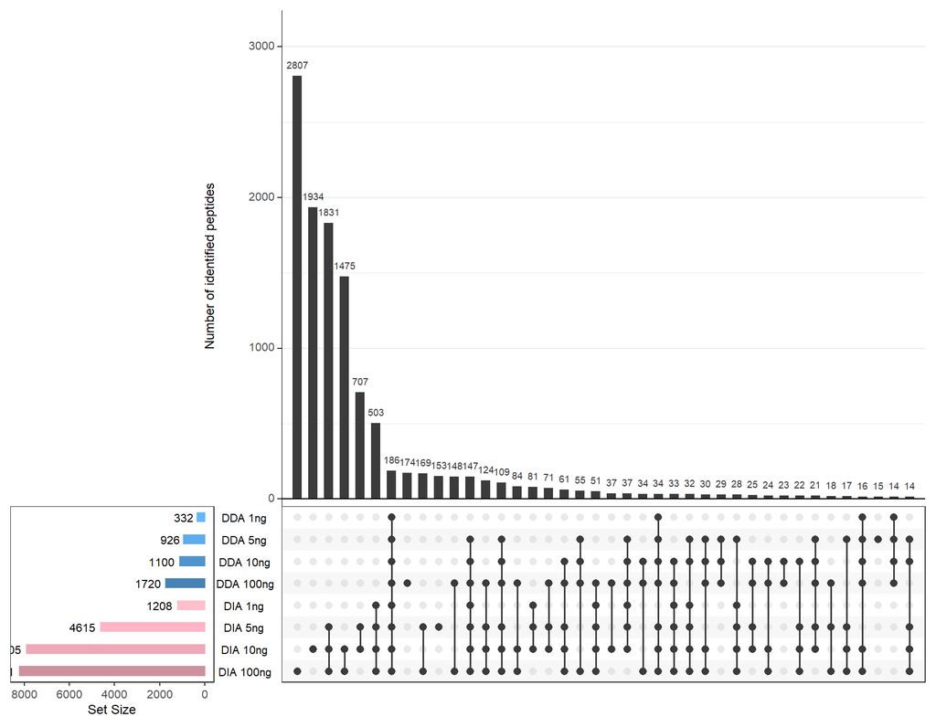

```r
pep_list <-
  list('DDA 1ng' = unique(DDA_1_filtered$Sequence),
       'DDA 5ng' = unique(DDA_5_filtered$Sequence),
       'DDA 10ng' = unique(DDA_10_filtered$Sequence),
       'DDA 100ng' = unique(DDA_100_filtered$Sequence),
       'DIA 1ng' = unique(DIA_1_filtered$PEP.StrippedSequence),
       'DIA 5ng' = unique(DIA_5_filtered$PEP.StrippedSequence),
       'DIA 10ng' = unique(DIA_10_filtered$PEP.StrippedSequence),
       'DIA 100ng' = unique(DIA_100_filtered$PEP.StrippedSequence))

palette <- c("pink3", "pink2", "pink1", "pink",
             "steelblue", "steelblue3", "steelblue2", "steelblue1")

upset(fromList(pep_list),
      sets = c('DIA 100ng', 'DIA 10ng', 'DIA 5ng', 'DIA 1ng',
               'DDA 100ng', 'DDA 10ng', 'DDA 5ng', 'DDA 1ng'),
      order.by = "freq",
      keep.order = TRUE,
      set_size.show = TRUE,
      sets.bar.color = palette,
      mainbar.y.label = "Number of identified peptides",
      nsets = 8,
      text.scale = 1.1)
```

# 3 Correlation

## 3.1 Load data

LIT Turbo DIA

```r
LITDIA_Turbo_1 <- read.csv2(paste0(lit_path, "20220420_LIT_Turbo_DIA_1ng_40SPD_whisper100_1CV_8ms.csv"))
LITDIA_Turbo_5 <- read.csv2(paste0(lit_path, "20220420_LIT_Turbo_DIA_5ng_40SPD_whisper100_1CV_8ms.csv"))
LITDIA_Turbo_10 <- read.csv2(paste0(lit_path, "20220420_LIT_Turbo_DIA_10ng_40SPD_whisper100_1CV_8ms.csv"))
LITDIA_Turbo_100 <- read.csv2(paste0(lit_path, "20220420_LIT_Turbo_DIA_100ng_40SPD_whisper100_1CV_8ms.csv"))

LITDIA_Turbo_1_auto <- read.csv2(paste0(lit_path, "20220502_LIT_Turbo_DIA_1ng_40SPD_whisper100_1CV_auto.csv"))
LITDIA_Turbo_5_auto <- read.csv2(paste0(lit_path, "20220502_LIT_Turbo_DIA_5ng_40SPD_whisper100_1CV_auto.csv"))
LITDIA_Turbo_10_auto <- read.csv2(paste0(lit_path, "20220502_LIT_Turbo_DIA_10ng_40SPD_whisper100_1CV_auto.csv"))
LITDIA_Turbo_100_auto <- read.csv2(paste0(lit_path, "20220502_LIT_Turbo_DIA_100ng_40SPD_whisper100_1CV_auto.csv"))

LITDIA_Turbo_1_auto$EG.IsImputed %>% table()
```

```
## .
## False  True
## 17120   124
```

LIT Rapid DIA

```r
LITDIA_Rapid_1 <- read.csv2(paste0(lit_path, "20220421_LIT_Rapid_DIA_1ng_40SPD_whisper100_1CV_auto.csv"))
LITDIA_Rapid_5 <- read.csv2(paste0(lit_path, "20220502_LIT_Rapid_DIA_5ng_40SPD_whisper100_1CV_auto.csv"))
LITDIA_Rapid_10 <- read.csv2(paste0(lit_path, "20220502_LIT_Rapid_DIA_10ng_40SPD_whisper100_1CV_auto.csv"))
LITDIA_Rapid_100 <- read.csv2(paste0(lit_path, "20220421_LIT_Rapid_DIA_100ng_40SPD_whisper100_1CV_auto.csv"))
```

LIT Normal DIA

```r
LITDIA_Normal_1 <- read.csv2(paste0(lit_path, "20220421_LIT_Normal_DIA_1ng_40SPD_whisper100_1CV_auto.csv"))
LITDIA_Normal_5 <- read.csv2(paste0(lit_path, "20220502_LIT_Normal_DIA_5ng_40SPD_whisper100_1CV_auto.csv"))
LITDIA_Normal_10 <- read.csv2(paste0(lit_path, "20220502_LIT_Normal_DIA_10ng_40SPD_whisper100_1CV_auto.csv"))
LITDIA_Normal_100 <- read.csv2(paste0(lit_path, "20220421_LIT_Normal_DIA_100ng_40SPD_whisper100_1CV_auto.csv"))
```

OT 7.5k DIA

```r
OTDIA_7k_1 <- read.csv2(paste0(ot_path, "20220421_OT_7k_DIA_1ng_40SPD_whisper100_1CV.csv"))
OTDIA_7k_5 <- read.csv2(paste0(ot_path, "20220502_OT_7k_DIA_5ng_40SPD_whisper100_1CV.csv"))
OTDIA_7k_10 <- read.csv2(paste0(ot_path, "20220502_OT_7k_DIA_10ng_40SPD_whisper100_1CV.csv"))
OTDIA_7k_100 <- read.csv2(paste0(ot_path, "20220421_OT_7k_DIA_100ng_40SPD_whisper100_1CV.csv"))
```

OT 15k DIA

```r
OTDIA_15k_1 <- read.csv2(paste0(ot_path, "20220421_OT_15k_DIA_1ng_40SPD_whisper100_1CV.csv"))
OTDIA_15k_5 <- read.csv2(paste0(ot_path, "20220509_OT_15k_DIA_5ng_40SPD_whisper100_1CV.csv"))
OTDIA_15k_10 <- read.csv2(paste0(ot_path, "20220502_OT_15k_DIA_10ng_40SPD_whisper100_1CV.csv"))
OTDIA_15k_100 <- read.csv2(paste0(ot_path, "20220425_OT_15k_DIA_100ng_40SPD_whisper100_1CV.csv"))
```

OT 30k DIA

```r
OTDIA_30k_1 <- read.csv2(paste0(ot_path, "20220421_OT_30k_DIA_1ng_40SPD_whisper100_1CV.csv"))
OTDIA_30k_5 <- read.csv2(paste0(ot_path, "20220509_OT_30k_DIA_5ng_40SPD_whisper100_1CV.csv"))
OTDIA_30k_10 <- read.csv2(paste0(ot_path, "20220502_OT_30k_DIA_10ng_40SPD_whisper100_1CV.csv"))
OTDIA_30k_100 <- read.csv2(paste0(ot_path, "20220425_OT_30k_DIA_100ng_40SPD_whisper100_1CV.csv"))
```

```r
filter_pep <- function(x) {
  x$FG.Quantity[as.logical(x$EG.IsImputed)] <- NA
  y <- x %>%
  group_by(R.FileName, PEP.StrippedSequence) %>%
  summarise(mean_quantity = mean(FG.Quantity, na.rm = TRUE)) %>%
  pivot_wider(names_from = R.FileName,
              values_from = mean_quantity) %>%
    suppressMessages()
  z <- y %>%
  mutate(na_nbr = rowSums(is.na(y[-1]))) %>%
  mutate(mean_quantity = rowMeans(y[2:ncol(y)], na.rm = TRUE)) %>%
  mutate(filtered = !na_nbr <= 1) %>%
  select(-na_nbr) %>%
  suppressMessages("`summarise()` has grouped output by 'R.FileName'. You can override using the `.groups` argument.")
  message("
Highlighted ", sum(z$filtered) , " peptide(s) found in less than ", ncol(y) -2, " replicates")

  return(z)
}
```

### 3.2.1 1 ng

```r
OTDIA_7k_1 <-  filter_pep(OTDIA_7k_1)
OTDIA_7k_1_filter <- OTDIA_7k_1[OTDIA_7k_1$filtered == FALSE,]
OTDIA_15k_1 <-  filter_pep(OTDIA_15k_1)
OTDIA_15k_1_filter <- OTDIA_15k_1[OTDIA_15k_1$filtered == FALSE,]
OTDIA_30k_1 <-  filter_pep(OTDIA_30k_1)
OTDIA_30k_1_filter <- OTDIA_30k_1[OTDIA_30k_1$filtered == FALSE,]

LITDIA_Turbo_1_auto <- filter_pep(LITDIA_Turbo_1_auto)
LITDIA_Turbo_1_auto_filter <- LITDIA_Turbo_1_auto[LITDIA_Turbo_1_auto$filtered == FALSE,]
LITDIA_Rapid_1 <- filter_pep(LITDIA_Rapid_1)
LITDIA_Rapid_1_filter <- LITDIA_Rapid_1[LITDIA_Rapid_1$filtered == FALSE,]
LITDIA_Normal_1 <- filter_pep(LITDIA_Normal_1)
LITDIA_Normal_1_filter <- LITDIA_Normal_1[LITDIA_Normal_1$filtered == FALSE,]
```

### 3.2.2 5 ng

```r
OTDIA_7k_5 <-  filter_pep(OTDIA_7k_5)
OTDIA_7k_5_filter <- OTDIA_7k_5[OTDIA_7k_5$filtered == FALSE,]
OTDIA_15k_5 <-  filter_pep(OTDIA_15k_5)
OTDIA_15k_5_filter <- OTDIA_15k_5[OTDIA_15k_5$filtered == FALSE,]
OTDIA_30k_5 <-  filter_pep(OTDIA_30k_5)
OTDIA_30k_5_filter <- OTDIA_30k_5[OTDIA_30k_5$filtered == FALSE,]

LITDIA_Turbo_5_auto <- filter_pep(LITDIA_Turbo_5_auto)
LITDIA_Turbo_5_auto_filter <- LITDIA_Turbo_5_auto[LITDIA_Turbo_5_auto$filtered == FALSE,]
LITDIA_Rapid_5 <- filter_pep(LITDIA_Rapid_5)
LITDIA_Rapid_5_filter <- LITDIA_Rapid_5[LITDIA_Rapid_5$filtered == FALSE,]
LITDIA_Normal_5 <- filter_pep(LITDIA_Normal_5)
LITDIA_Normal_5_filter <- LITDIA_Normal_5[LITDIA_Normal_5$filtered == FALSE,]
```

### 3.2.3 10 ng

```r
OTDIA_7k_10 <-  filter_pep(OTDIA_7k_10)
OTDIA_7k_10_filter <- OTDIA_7k_10[OTDIA_7k_10$filtered == FALSE,]
OTDIA_15k_10 <-  filter_pep(OTDIA_15k_10)
OTDIA_15k_10_filter <- OTDIA_15k_10[OTDIA_15k_10$filtered == FALSE,]
OTDIA_30k_10 <-  filter_pep(OTDIA_30k_10)
OTDIA_30k_10_filter <- OTDIA_30k_10[OTDIA_30k_10$filtered == FALSE,]

LITDIA_Turbo_10_auto <- filter_pep(LITDIA_Turbo_10_auto)
LITDIA_Turbo_10_auto_filter <- LITDIA_Turbo_10_auto[LITDIA_Turbo_10_auto$filtered == FALSE,]
LITDIA_Rapid_10 <- filter_pep(LITDIA_Rapid_10)
LITDIA_Rapid_10_filter <- LITDIA_Rapid_10[LITDIA_Rapid_10$filtered == FALSE,]
LITDIA_Normal_10 <- filter_pep(LITDIA_Normal_10)
LITDIA_Normal_10_filter <- LITDIA_Normal_10[LITDIA_Normal_10$filtered == FALSE,]
```

### 3.2.4 100 ng

```r
OTDIA_7k_100 <-  filter_pep(OTDIA_7k_100)
OTDIA_7k_100_filter <- OTDIA_7k_100[OTDIA_7k_100$filtered == FALSE,]
OTDIA_15k_100 <-  filter_pep(OTDIA_15k_100)
OTDIA_15k_100_filter <- OTDIA_15k_100[OTDIA_15k_100$filtered == FALSE,]
OTDIA_30k_100 <-  filter_pep(OTDIA_30k_100)
OTDIA_30k_100_filter <- OTDIA_30k_100[OTDIA_30k_100$filtered == FALSE,]

LITDIA_Turbo_100_auto <- filter_pep(LITDIA_Turbo_100_auto)
LITDIA_Turbo_100_auto_filter <- LITDIA_Turbo_100_auto[LITDIA_Turbo_100_auto$filtered == FALSE,]
LITDIA_Rapid_100 <- filter_pep(LITDIA_Rapid_100)
LITDIA_Rapid_100_filter <- LITDIA_Rapid_100[LITDIA_Rapid_100$filtered == FALSE,]
LITDIA_Normal_100 <- filter_pep(LITDIA_Normal_100)
LITDIA_Normal_100_filter <- LITDIA_Normal_100[LITDIA_Normal_100$filtered == FALSE,]
```

## 3.3 Correlation plot

### 3.3.1 1 ng

```r
Turbo_vs_7k_1_facet <-
  inner_join(OTDIA_7k_1_filter[,c(1,6)],
             LITDIA_Turbo_1_auto_filter[,c(1,6)],
             by = "PEP.StrippedSequence",
             suffix = c("_OT", "_LIT"))
Turbo_vs_7k_1_facet$method <- "LIT Turbo vs OT 7.5k"
Turbo_vs_7k_1_facet$input <- "1 ng"

Rapid_vs_15k_1_facet <-
  inner_join(OTDIA_15k_1_filter[,c(1,6)],
             LITDIA_Rapid_1_filter[,c(1,6)],
             by = "PEP.StrippedSequence",
             suffix = c("_OT", "_LIT"))
Rapid_vs_15k_1_facet$method <- "LIT Rapid vs OT 15k"
Rapid_vs_15k_1_facet$input <- "1 ng"

Normal_vs_30k_1_facet <-
  inner_join(OTDIA_30k_1_filter[,c(1,6)],
             LITDIA_Normal_1_filter[,c(1,6)],
             by = "PEP.StrippedSequence",
             suffix = c("_OT", "_LIT"))
Normal_vs_30k_1_facet$method <- "LIT Normal vs OT 30k"
Normal_vs_30k_1_facet$input <- "1 ng"
```

### 3.3.2 5 ng

```r
Turbo_vs_7k_5_facet <-
  inner_join(OTDIA_7k_5_filter[,c(1,6)],
             LITDIA_Turbo_5_auto_filter[,c(1,6)],
             by = "PEP.StrippedSequence",
             suffix = c("_OT", "_LIT"))
Turbo_vs_7k_5_facet$method <- "LIT Turbo vs OT 7.5k"
Turbo_vs_7k_5_facet$input <- "5 ng"

Rapid_vs_15k_5_facet <-
  inner_join(OTDIA_15k_5_filter[,c(1,6)],
             LITDIA_Rapid_5_filter[,c(1,6)],
             by = "PEP.StrippedSequence",
             suffix = c("_OT", "_LIT"))
Rapid_vs_15k_5_facet$method <- "LIT Rapid vs OT 15k"
Rapid_vs_15k_5_facet$input <- "5 ng"

Normal_vs_30k_5_facet <-
  inner_join(OTDIA_30k_5_filter[,c(1,6)],
             LITDIA_Normal_5_filter[,c(1,6)],
             by = "PEP.StrippedSequence",
             suffix = c("_OT", "_LIT"))
Normal_vs_30k_5_facet$method <- "LIT Normal vs OT 30k"
Normal_vs_30k_5_facet$input <- "5 ng"
```

### 3.3.3 10 ng

```r
Turbo_vs_7k_10_facet <-
  inner_join(OTDIA_7k_10_filter[,c(1,6)],
             LITDIA_Turbo_10_auto_filter[,c(1,6)],
             by = "PEP.StrippedSequence",
             suffix = c("_OT", "_LIT"))
Turbo_vs_7k_10_facet$method <- "LIT Turbo vs OT 7.5k"
Turbo_vs_7k_10_facet$input <- "10 ng"

Rapid_vs_15k_10_facet <-
  inner_join(OTDIA_15k_10_filter[,c(1,6)],
             LITDIA_Rapid_10_filter[,c(1,6)],
             by = "PEP.StrippedSequence",
             suffix = c("_OT", "_LIT"))
Rapid_vs_15k_10_facet$method <- "LIT Rapid vs OT 15k"
Rapid_vs_15k_10_facet$input <- "10 ng"

Normal_vs_30k_10_facet <-
  inner_join(OTDIA_30k_10_filter[,c(1,6)],
             LITDIA_Normal_10_filter[,c(1,6)],
             by = "PEP.StrippedSequence",
             suffix = c("_OT", "_LIT"))
Normal_vs_30k_10_facet$method <- "LIT Normal vs OT 30k"
Normal_vs_30k_10_facet$input <- "10 ng"
```

### 3.3.4 100 ng

```r
Turbo_vs_7k_100_facet <-
  inner_join(OTDIA_7k_100_filter[,c(1,6)],
             LITDIA_Turbo_100_auto_filter[,c(1,6)],
             by = "PEP.StrippedSequence",
             suffix = c("_OT", "_LIT"))
Turbo_vs_7k_100_facet$method <- "LIT Turbo vs OT 7.5k"
Turbo_vs_7k_100_facet$input <- "100 ng"

Rapid_vs_15k_100_facet <-
  inner_join(OTDIA_15k_100_filter[,c(1,6)],
             LITDIA_Rapid_100_filter[,c(1,6)],
             by = "PEP.StrippedSequence",
             suffix = c("_OT", "_LIT"))
Rapid_vs_15k_100_facet$method <- "LIT Rapid vs OT 15k"
Rapid_vs_15k_100_facet$input <- "100 ng"

Normal_vs_30k_100_facet <-
  inner_join(OTDIA_30k_100_filter[,c(1,6)],
             LITDIA_Normal_100_filter[,c(1,6)],
             by = "PEP.StrippedSequence",
             suffix = c("_OT", "_LIT"))
Normal_vs_30k_100_facet$method <- "LIT Normal vs OT 30k"
Normal_vs_30k_100_facet$input <- "100 ng"
```

### 3.3.5 Join

```r
facet <- rbind(Turbo_vs_7k_1_facet, Rapid_vs_15k_1_facet, Normal_vs_30k_1_facet,
               Turbo_vs_7k_5_facet, Rapid_vs_15k_5_facet, Normal_vs_30k_5_facet,
               Turbo_vs_7k_10_facet, Rapid_vs_15k_10_facet, Normal_vs_30k_10_facet,
               Turbo_vs_7k_100_facet, Rapid_vs_15k_100_facet, Normal_vs_30k_100_facet)

facet$method <- factor(facet$method,
                       levels = c("LIT Turbo vs OT 7.5k",
                                  "LIT Rapid vs OT 15k",
                                  "LIT Normal vs OT 30k"))
facet$input = factor(facet$input, levels = unique(facet$input))
```

### 3.3.6 Plot

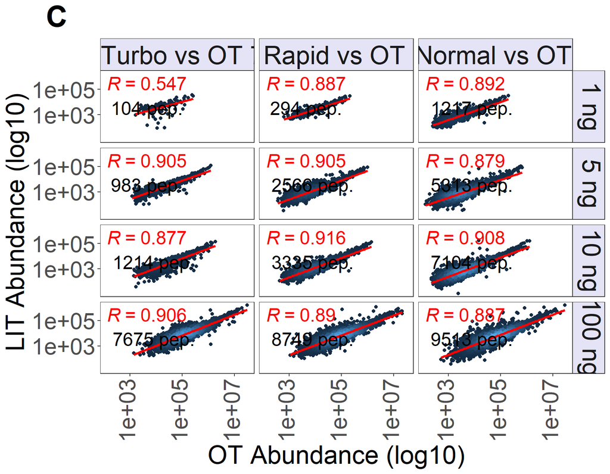

```r
corr_plot <- facet %>%
  ggplot(aes(x = mean_quantity_OT, y = mean_quantity_LIT)) +
  geom_pointdensity(size = 1.5)+
  theme(legend.position = "none",
        axis.text.x = element_text(angle = 90,
                                   vjust = 0.3),
        panel.grid = element_blank(),
        axis.title = element_text(size = 27),
        axis.text = element_text(size = 24),
        strip.text.x = element_text(size = 27),
        strip.text.y = element_text(size = 27, vjust = 1.2),
        strip.background = element_rect(fill = "#E5E4F7"),
        plot.title = element_text(size = 32, face = "bold",
                                  hjust = -0.12)) +
  geom_smooth(method = lm,
              se = FALSE,
              color = "red",
              size = 1.2)+
  stat_cor(method = "pearson",
           aes(label = ..r.label..),
           r.digits = 3, color = "red",
           size = 7,
           label.x.npc = 0,
           label.y.npc = 0.9)+
  labs(x = "OT Abundance (log10)",
       y = "LIT Abundance (log10)",
       title = "C") +
  scale_y_log10(breaks = c(1000, 100000)) +
  scale_x_log10() +
  facet_grid(input~method)

labels <- paste0(c(sum(facet$method == "LIT Turbo vs OT 7.5k" & facet$input == "1 ng"),
                   sum(facet$method == "LIT Rapid vs OT 15k" & facet$input == "1 ng"),
                   sum(facet$method == "LIT Normal vs OT 30k" & facet$input == "1 ng"),
                   sum(facet$method == "LIT Turbo vs OT 7.5k" & facet$input == "5 ng"),
                   sum(facet$method == "LIT Rapid vs OT 15k" & facet$input == "5 ng"),
                   sum(facet$method == "LIT Normal vs OT 30k" & facet$input == "5 ng"),
                   sum(facet$method == "LIT Turbo vs OT 7.5k" & facet$input == "10 ng"),
                   sum(facet$method == "LIT Rapid vs OT 15k" & facet$input == "10 ng"),
                   sum(facet$method == "LIT Normal vs OT 30k" & facet$input == "10 ng"),
                   sum(facet$method == "LIT Turbo vs OT 7.5k" & facet$input == "100 ng"),
                   sum(facet$method == "LIT Rapid vs OT 15k" & facet$input == "100 ng"),
                   sum(facet$method == "LIT Normal vs OT 30k" & facet$input == "100 ng")),
                 " pep.")

data_labels <-
  data.frame(method = as.factor(rep(c("LIT Turbo vs OT 7.5k",
                                      "LIT Rapid vs OT 15k",
                                      "LIT Normal vs OT 30k"),4)),
             input = as.factor(c(rep("1 ng",3), rep("5 ng",3),rep("10 ng",3), rep("100 ng",3))),
             label = labels)

corr_plot <- corr_plot +
  geom_text(x = -Inf, y = Inf,
            hjust = -0.15, vjust = 3.2,
            aes(label = labels, group = NULL), data = data_labels,
            size = 7,
            face = "bold")
corr_plot
```

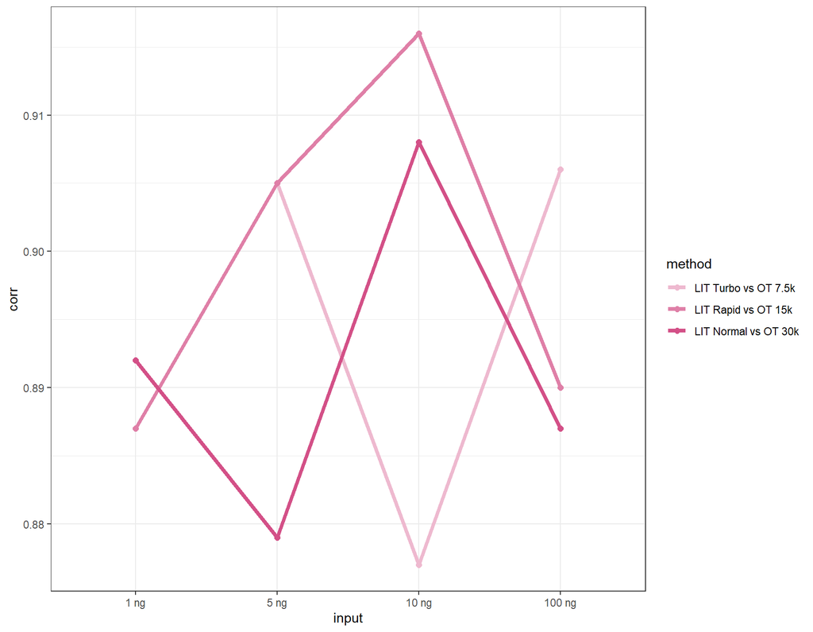

```r
temp <- data.frame(corr = c(NA, 0.887, 0.892, 0.905, 0.905, 0.879, 0.877, 0.916, 0.908, 0.906, 0.89, 0.887),
           input = c(rep("1 ng", 3), rep("5 ng", 3), rep("10 ng", 3), rep("100 ng", 3)),
           method = rep(c("LIT Turbo vs OT 7.5k",
                                      "LIT Rapid vs OT 15k",
                                      "LIT Normal vs OT 30k"),4))

temp$method <- factor(temp$method, levels = unique(temp$method))
temp$input <- factor(temp$input, levels = unique(temp$input))


temp %>%
  ggplot(aes(x = input, y = corr, group = method, color = method))+
  geom_line(size = 1.5)+
  geom_point(size = 2)+
  scale_color_manual(values =  c("#EEB9CF", "#DF7FA7", "#D35087"))
```

# 4 LIT Abundance distribution

## 4.1 Highlight peptides found in corresponding OT method

### 4.1.1 1 ng

```r
#Turbo
LITDIA_Turbo_1_auto_filter$in_OT <-
  LITDIA_Turbo_1_auto_filter$PEP.StrippedSequence %in%
  OTDIA_7k_1_filter$PEP.StrippedSequence
LITDIA_Turbo_1_auto_filter$method <- "Turbo"

#Rapid
LITDIA_Rapid_1_filter$in_OT <-
  LITDIA_Rapid_1_filter$PEP.StrippedSequence %in%
  OTDIA_15k_1_filter$PEP.StrippedSequence
LITDIA_Rapid_1_filter$method <- "Rapid"

#Normal
LITDIA_Normal_1_filter$in_OT <-
  LITDIA_Normal_1_filter$PEP.StrippedSequence %in%
  OTDIA_30k_1_filter$PEP.StrippedSequence
LITDIA_Normal_1_filter$method <- "Normal"

#Input
LITDIA_Turbo_1_auto_filter$input <-
  LITDIA_Rapid_1_filter$input <-
  LITDIA_Normal_1_filter$input <- "1 ng"
```

### 4.1.2 5 ng

```r
#Turbo
LITDIA_Turbo_5_auto_filter$in_OT <-
  LITDIA_Turbo_5_auto_filter$PEP.StrippedSequence %in%
  OTDIA_7k_5_filter$PEP.StrippedSequence
LITDIA_Turbo_5_auto_filter$method <- "Turbo"

#Rapid
LITDIA_Rapid_5_filter$in_OT <-
  LITDIA_Rapid_5_filter$PEP.StrippedSequence %in%
  OTDIA_15k_5_filter$PEP.StrippedSequence
LITDIA_Rapid_5_filter$method <- "Rapid"

#Normal
LITDIA_Normal_5_filter$in_OT <-
  LITDIA_Normal_5_filter$PEP.StrippedSequence %in%
  OTDIA_30k_5_filter$PEP.StrippedSequence
LITDIA_Normal_5_filter$method <- "Normal"

#Input
LITDIA_Turbo_5_auto_filter$input <-
  LITDIA_Rapid_5_filter$input <-
  LITDIA_Normal_5_filter$input <- "5 ng"
```

### 4.1.3 10 ng

```r
#Turbo
LITDIA_Turbo_10_auto_filter$in_OT <-
  LITDIA_Turbo_10_auto_filter$PEP.StrippedSequence %in%
  OTDIA_7k_10_filter$PEP.StrippedSequence
LITDIA_Turbo_10_auto_filter$method <- "Turbo"

#Rapid
LITDIA_Rapid_10_filter$in_OT <-
  LITDIA_Rapid_10_filter$PEP.StrippedSequence %in%
  OTDIA_15k_10_filter$PEP.StrippedSequence
LITDIA_Rapid_10_filter$method <- "Rapid"

#Normal
LITDIA_Normal_10_filter$in_OT <-
  LITDIA_Normal_10_filter$PEP.StrippedSequence %in%
  OTDIA_30k_10_filter$PEP.StrippedSequence
LITDIA_Normal_10_filter$method <- "Normal"

#Input
LITDIA_Turbo_10_auto_filter$input <-
  LITDIA_Rapid_10_filter$input <-
  LITDIA_Normal_10_filter$input <- "10 ng"
```

### 4.1.4 100 ng

```r
#Turbo
LITDIA_Turbo_100_auto_filter$in_OT <-
  LITDIA_Turbo_100_auto_filter$PEP.StrippedSequence %in%
  OTDIA_7k_100_filter$PEP.StrippedSequence
LITDIA_Turbo_100_auto_filter$method <- "Turbo"

#Rapid
LITDIA_Rapid_100_filter$in_OT <-
  LITDIA_Rapid_100_filter$PEP.StrippedSequence %in%
  OTDIA_15k_100_filter$PEP.StrippedSequence
LITDIA_Rapid_100_filter$method <- "Rapid"

#Normal
LITDIA_Normal_100_filter$in_OT <-
  LITDIA_Normal_100_filter$PEP.StrippedSequence %in%
  OTDIA_30k_100_filter$PEP.StrippedSequence
LITDIA_Normal_100_filter$method <- "Normal"

#Input
LITDIA_Turbo_100_auto_filter$input <-
  LITDIA_Rapid_100_filter$input <-
  LITDIA_Normal_100_filter$input <- "100 ng"
```

## 4.2 Joining

```r
OT_in_LIT <-
  rbind(LITDIA_Turbo_1_auto_filter[,c(1,6:10)], LITDIA_Turbo_5_auto_filter[,c(1,6:10)],
        LITDIA_Turbo_10_auto_filter[,c(1,6:10)], LITDIA_Turbo_100_auto_filter[,c(1,6:10)],
        LITDIA_Rapid_1_filter[,c(1,6:10)], LITDIA_Rapid_5_filter[,c(1,6:10)],
        LITDIA_Rapid_10_filter[,c(1,6:10)], LITDIA_Rapid_100_filter[,c(1,6:10)],
        LITDIA_Normal_1_filter[,c(1,6:10)], LITDIA_Normal_5_filter[,c(1,6:10)],
        LITDIA_Normal_10_filter[,c(1,6:10)], LITDIA_Normal_100_filter[,c(1,6:10)])

OT_in_LIT$method <- factor(OT_in_LIT$method,
                       levels = unique(OT_in_LIT$method))
OT_in_LIT$input <- factor(OT_in_LIT$input,
                       levels = unique(OT_in_LIT$input))
```

## 4.3 Plot

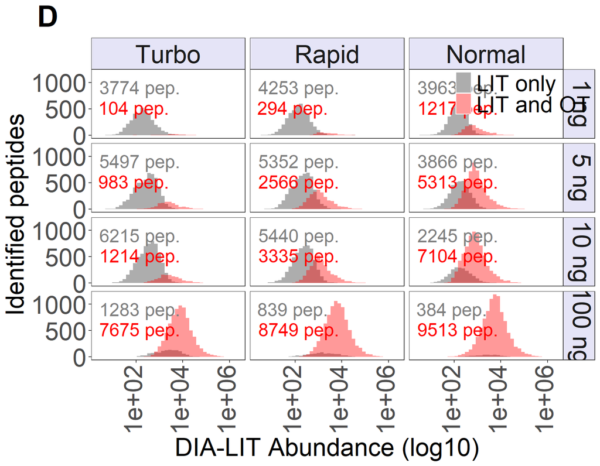

```r
OT_in_LIT_plot <- OT_in_LIT %>%
  ggplot(aes(x = mean_quantity, fill = in_OT))+
  geom_histogram(bins = 40,
                 position = "identity",
                 alpha = 0.4)+
  scale_x_log10()+
  scale_y_continuous(breaks = c(0, 500, 1000)) +
  scale_fill_manual(values = c("grey20", "red"),
                    labels = c("LIT only", "LIT and OT"))+
  labs(x = "DIA-LIT Abundance (log10)",
       y = "Identified peptides",
       title = "D")+
  theme(axis.text.x = element_text(angle = 90,
                                   vjust = 0.3),
        panel.grid = element_blank(),
        legend.position = c(0.915, 0.927),
        legend.background = element_blank(),
        axis.title = element_text(size = 27),
        axis.text = element_text(size = 27),
        legend.title = element_blank(),
        legend.text = element_text(size = 24),
        strip.text.x = element_text(size = 27),
        strip.text.y = element_text(size = 27, vjust = 1.2),
        strip.background = element_rect(fill = "#E5E4F7"),
        plot.title = element_text(size = 32, face = "bold",
                                  hjust = -0.12)) +
  facet_grid(input ~ method)

labels1 <-
  paste0(c(sum(OT_in_LIT$method == "Turbo" & OT_in_LIT$input == "1 ng" & OT_in_LIT$in_OT == FALSE),
           sum(OT_in_LIT$method == "Rapid" & OT_in_LIT$input == "1 ng" & OT_in_LIT$in_OT == FALSE),
           sum(OT_in_LIT$method == "Normal" & OT_in_LIT$input == "1 ng" & OT_in_LIT$in_OT == FALSE),
           sum(OT_in_LIT$method == "Turbo" & OT_in_LIT$input == "5 ng" & OT_in_LIT$in_OT == FALSE),
           sum(OT_in_LIT$method == "Rapid" & OT_in_LIT$input == "5 ng" & OT_in_LIT$in_OT == FALSE),
           sum(OT_in_LIT$method == "Normal" & OT_in_LIT$input == "5 ng" & OT_in_LIT$in_OT == FALSE),
           sum(OT_in_LIT$method == "Turbo" & OT_in_LIT$input == "10 ng" & OT_in_LIT$in_OT == FALSE),
           sum(OT_in_LIT$method == "Rapid" & OT_in_LIT$input == "10 ng" & OT_in_LIT$in_OT == FALSE),
           sum(OT_in_LIT$method == "Normal" & OT_in_LIT$input == "10 ng" & OT_in_LIT$in_OT == FALSE),
           sum(OT_in_LIT$method == "Turbo" & OT_in_LIT$input == "100 ng" & OT_in_LIT$in_OT == FALSE),
           sum(OT_in_LIT$method == "Rapid" &  OT_in_LIT$input == "100 ng" & OT_in_LIT$in_OT == FALSE),
           sum(OT_in_LIT$method == "Normal" & OT_in_LIT$input == "100 ng" & OT_in_LIT$in_OT == FALSE)),
         " pep.")


data_labels1 <-
  data.frame(method = as.factor(rep(c("Turbo", "Rapid", "Normal"),4)),
             input = as.factor(c(rep("1 ng",3), rep("5 ng",3), rep("10 ng",3), rep("100 ng",3))),
             label = labels1,
             in_OT = rep(FALSE, 12))

labels2<-
  paste0(c(sum(OT_in_LIT$method == "Turbo" & OT_in_LIT$input == "1 ng" & OT_in_LIT$in_OT == TRUE),
           sum(OT_in_LIT$method == "Rapid" & OT_in_LIT$input == "1 ng" & OT_in_LIT$in_OT == TRUE),
           sum(OT_in_LIT$method == "Normal" & OT_in_LIT$input == "1 ng" & OT_in_LIT$in_OT == TRUE),
           sum(OT_in_LIT$method == "Turbo" & OT_in_LIT$input == "5 ng" & OT_in_LIT$in_OT == TRUE),
           sum(OT_in_LIT$method == "Rapid" & OT_in_LIT$input == "5 ng" & OT_in_LIT$in_OT == TRUE),
           sum(OT_in_LIT$method == "Normal" & OT_in_LIT$input == "5 ng" & OT_in_LIT$in_OT == TRUE),
           sum(OT_in_LIT$method == "Turbo" & OT_in_LIT$input == "10 ng" & OT_in_LIT$in_OT == TRUE),
           sum(OT_in_LIT$method == "Rapid" & OT_in_LIT$input == "10 ng" & OT_in_LIT$in_OT == TRUE),
           sum(OT_in_LIT$method == "Normal" & OT_in_LIT$input == "10 ng" & OT_in_LIT$in_OT == TRUE),
           sum(OT_in_LIT$method == "Turbo" & OT_in_LIT$input == "100 ng" & OT_in_LIT$in_OT == TRUE),
           sum(OT_in_LIT$method == "Rapid" &  OT_in_LIT$input == "100 ng" & OT_in_LIT$in_OT == TRUE),
           sum(OT_in_LIT$method == "Normal" & OT_in_LIT$input == "100 ng" & OT_in_LIT$in_OT == TRUE)),
         " pep.")

data_labels2 <-
  data.frame(method = as.factor(rep(c("Turbo", "Rapid", "Normal"),4)),
             input = as.factor(c(rep("1 ng",3), rep("5 ng",3), rep("10 ng",3), rep("100 ng",3))),
             label = labels2,
             in_OT = rep(TRUE, 12))

OT_in_LIT_plot <- OT_in_LIT_plot +
  geom_text(x = -Inf, y = Inf,
            hjust = -0.1, vjust = 1.82,
            aes(label = label, group = NULL), data = data_labels1,
            color = "grey50",
            size = 7,
            face = "bold")+
  geom_text(x = -Inf, y = Inf,
            hjust = -0.1, vjust = 3.32,
            aes(label = label, group = NULL), data = data_labels2,
            color = "red",
            size = 7,
            face = "bold")
OT_in_LIT_plot
```

## 4.4 temp

### 4.4.1 Turbo

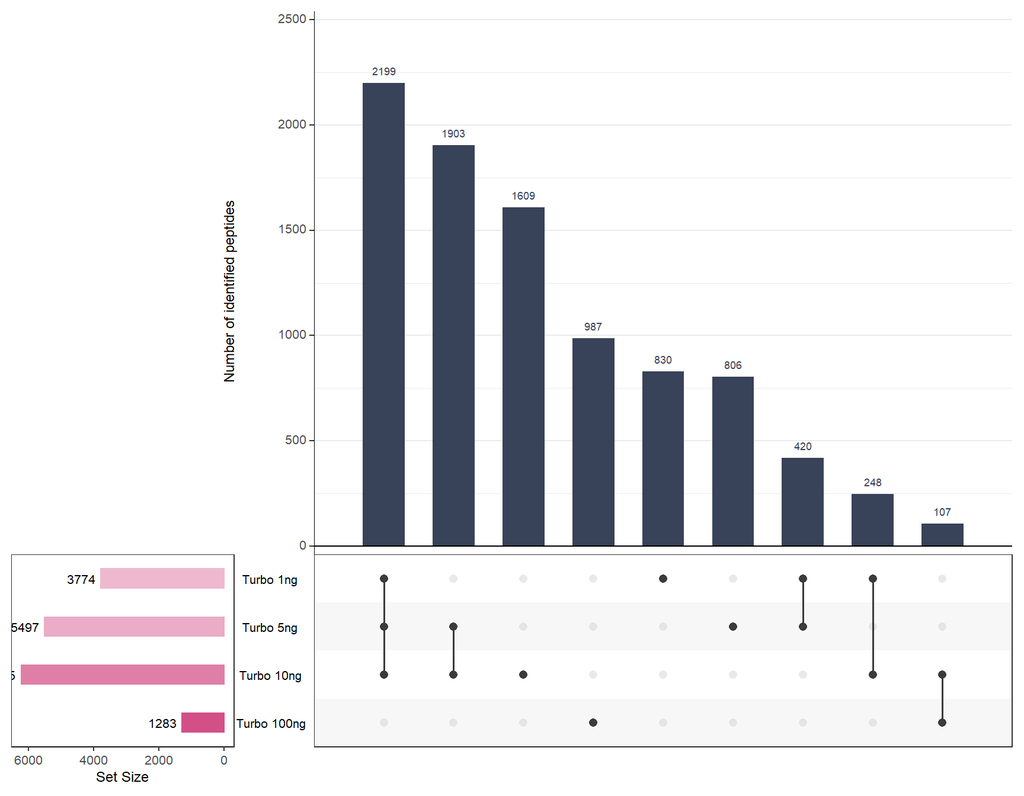

```r
seq_Turbo_1 <- OT_in_LIT %>%
  filter(in_OT == FALSE & method == "Turbo" & input == "1 ng") %>%
  pull(PEP.StrippedSequence)
seq_Turbo_5 <- OT_in_LIT %>%
  filter(in_OT == FALSE & method == "Turbo" & input == "5 ng") %>%
  pull(PEP.StrippedSequence)
seq_Turbo_10 <- OT_in_LIT %>%
  filter(in_OT == FALSE & method == "Turbo" & input == "10 ng") %>%
  pull(PEP.StrippedSequence)
seq_Turbo_100 <- OT_in_LIT %>%
  filter(in_OT == FALSE & method == "Turbo" & input == "100 ng") %>%
  pull(PEP.StrippedSequence)

seq_list <-
  list('Turbo 1ng' = seq_Turbo_1,
       'Turbo 5ng' = seq_Turbo_5,
       'Turbo 10ng' = seq_Turbo_10,
       'Turbo 100ng' = seq_Turbo_100)

upset_Turbo <- upset(fromList(seq_list),
      sets = c('Turbo 100ng', 'Turbo 10ng', 'Turbo 5ng', 'Turbo 1ng'),
      order.by = "freq",
      keep.order = TRUE,
      set_size.show = TRUE,
      mainbar.y.label = "Number of identified peptides",
      text.scale = 1.1,
      sets.bar.color = teera_palette[c(3, 2, 4, 1)],
      main.bar.color = "#384258",
      nintersects = 9)
upset_Turbo
```

### 4.4.2 Rapid

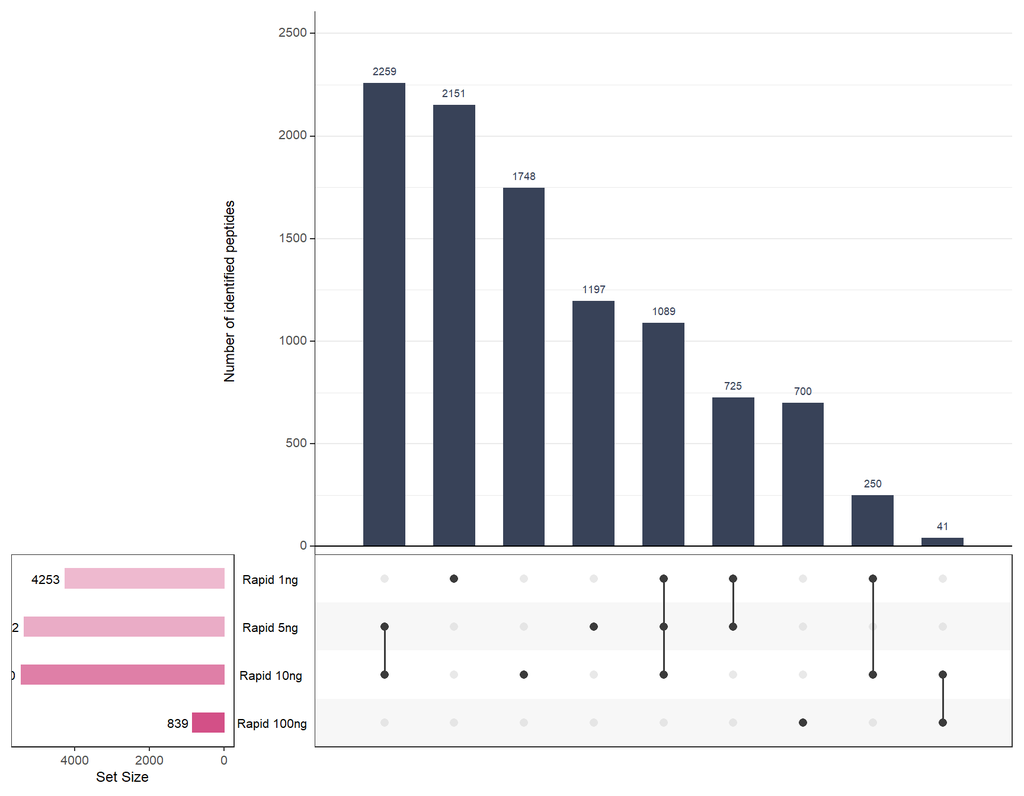

```r
seq_Rapid_1 <- OT_in_LIT %>%
  filter(in_OT == FALSE & method == "Rapid" & input == "1 ng") %>%
  pull(PEP.StrippedSequence)
seq_Rapid_5 <- OT_in_LIT %>%
  filter(in_OT == FALSE & method == "Rapid" & input == "5 ng") %>%
  pull(PEP.StrippedSequence)
seq_Rapid_10 <- OT_in_LIT %>%
  filter(in_OT == FALSE & method == "Rapid" & input == "10 ng") %>%
  pull(PEP.StrippedSequence)
seq_Rapid_100 <- OT_in_LIT %>%
  filter(in_OT == FALSE & method == "Rapid" & input == "100 ng") %>%
  pull(PEP.StrippedSequence)

seq_list <-
  list('Rapid 1ng' = seq_Rapid_1,
       'Rapid 5ng' = seq_Rapid_5,
       'Rapid 10ng' = seq_Rapid_10,
       'Rapid 100ng' = seq_Rapid_100)

upset_Rapid <- upset(fromList(seq_list),
      sets = c('Rapid 100ng', 'Rapid 10ng', 'Rapid 5ng', 'Rapid 1ng'),
      order.by = "freq",
      keep.order = TRUE,
      set_size.show = TRUE,
      mainbar.y.label = "Number of identified peptides",
      text.scale = 1.1,
      sets.bar.color = teera_palette[c(3, 2, 4, 1)],
      main.bar.color = "#384258",
      nintersects = 9)
upset_Rapid
```

### 4.4.3 Normal

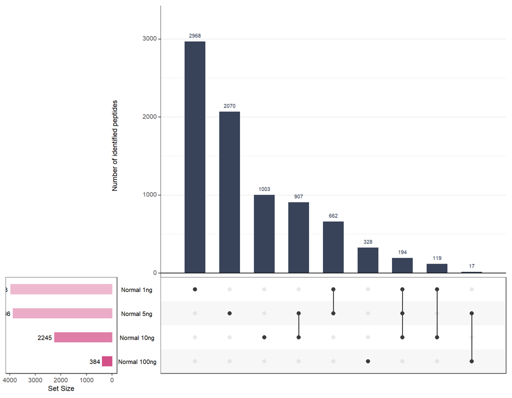

```r
seq_Normal_1 <- OT_in_LIT %>%
  filter(in_OT == FALSE & method == "Normal" & input == "1 ng") %>%
  pull(PEP.StrippedSequence)
seq_Normal_5 <- OT_in_LIT %>%
  filter(in_OT == FALSE & method == "Normal" & input == "5 ng") %>%
  pull(PEP.StrippedSequence)
seq_Normal_10 <- OT_in_LIT %>%
  filter(in_OT == FALSE & method == "Normal" & input == "10 ng") %>%
  pull(PEP.StrippedSequence)
seq_Normal_100 <- OT_in_LIT %>%
  filter(in_OT == FALSE & method == "Normal" & input == "100 ng") %>%
  pull(PEP.StrippedSequence)

seq_list <-
  list('Normal 1ng' = seq_Normal_1,
       'Normal 5ng' = seq_Normal_5,
       'Normal 10ng' = seq_Normal_10,
       'Normal 100ng' = seq_Normal_100)

upset_Normal <- upset(fromList(seq_list),
      sets = c('Normal 100ng', 'Normal 10ng', 'Normal 5ng', 'Normal 1ng'),
      order.by = "freq",
      keep.order = TRUE,
      set_size.show = TRUE,
      mainbar.y.label = "Number of identified peptides",
      text.scale = 1.1,
      sets.bar.color = teera_palette[c(3, 2, 4, 1)],
      nintersects = 9,
      main.bar.color = "#384258")
upset_Normal
```

### 4.4.4 1 ng

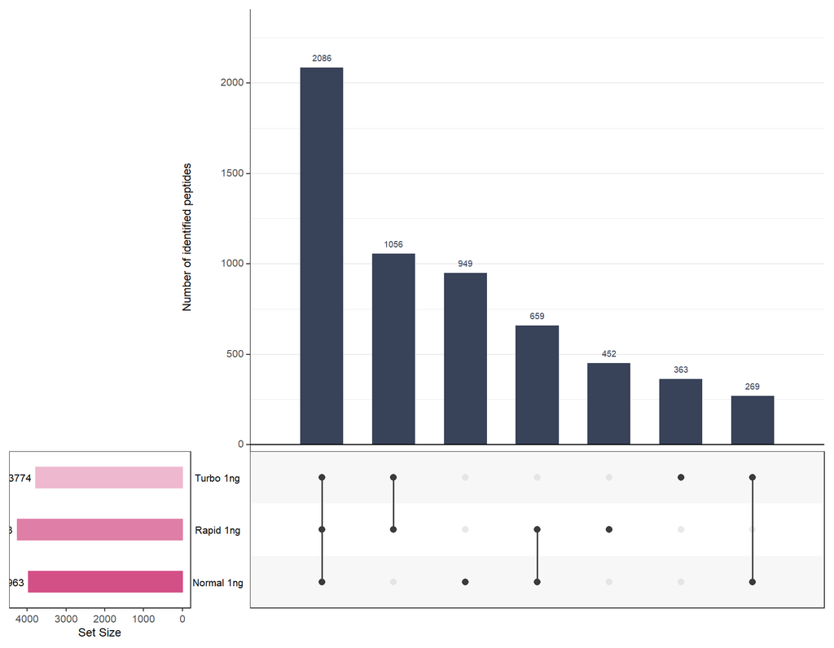

```r
seq_list <-
  list('Turbo 1ng' = seq_Turbo_1,
       'Rapid 1ng' = seq_Rapid_1,
       'Normal 1ng' = seq_Normal_1)

upset_1ng <- upset(fromList(seq_list),
      sets = c('Normal 1ng', 'Rapid 1ng', 'Turbo 1ng'),
      order.by = "freq",
      keep.order = TRUE,
      set_size.show = TRUE,
      mainbar.y.label = "Number of identified peptides",
      text.scale = 1.1,
      sets.bar.color = c("#D35087", "#DF7FA7", "#EEB9CF"),
      empty.intersections = TRUE,
      main.bar.color = "#384258")
upset_1ng
```

### 4.4.5 5 ng

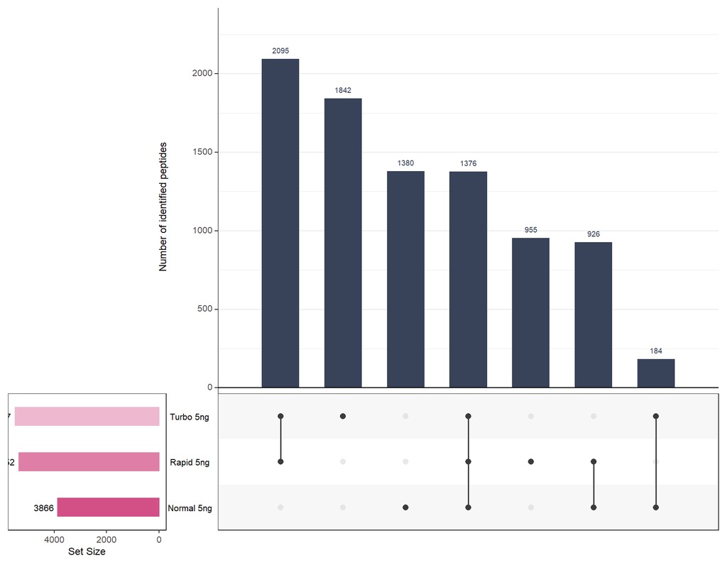

```r
seq_list <-
  list('Turbo 5ng' = seq_Turbo_5,
       'Rapid 5ng' = seq_Rapid_5,
       'Normal 5ng' = seq_Normal_5)

upset_5ng <- upset(fromList(seq_list),
      sets = c('Normal 5ng', 'Rapid 5ng', 'Turbo 5ng'),
      order.by = "freq",
      keep.order = TRUE,
      set_size.show = TRUE,
      mainbar.y.label = "Number of identified peptides",
      text.scale = 1.1,
      sets.bar.color = c("#D35087", "#DF7FA7", "#EEB9CF"),
      main.bar.color = "#384258")
upset_5ng
```

### 4.4.6 10 ng

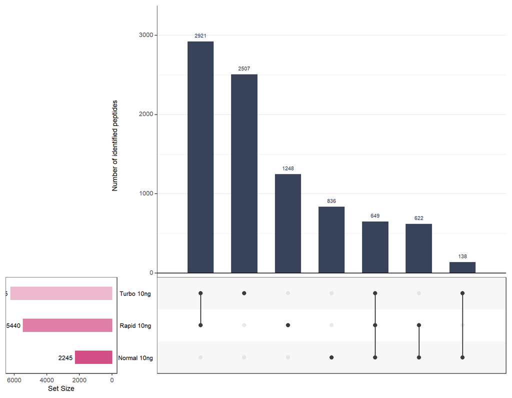

```r
seq_list <-
  list('Turbo 10ng' = seq_Turbo_10,
       'Rapid 10ng' = seq_Rapid_10,
       'Normal 10ng' = seq_Normal_10)

upset_10ng <- upset(fromList(seq_list),
      sets = c('Normal 10ng', 'Rapid 10ng', 'Turbo 10ng'),
      order.by = "freq",
      keep.order = TRUE,
      set_size.show = TRUE,
      mainbar.y.label = "Number of identified peptides",
      text.scale = 1.1,
      sets.bar.color = c("#D35087", "#DF7FA7", "#EEB9CF"),
      main.bar.color = "#384258")
upset_10ng
```

### 4.4.7 100 ng

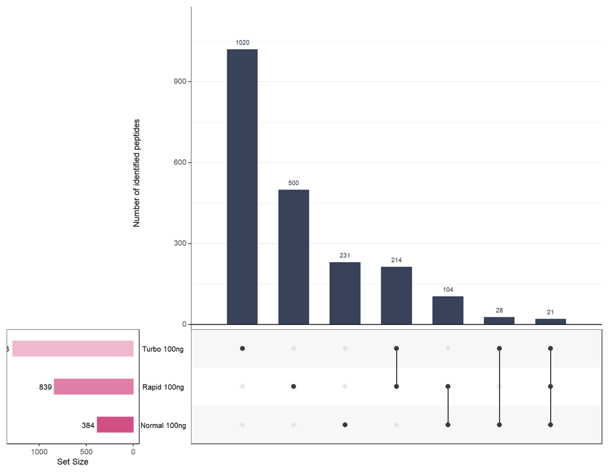

```r
seq_list <-
  list('Turbo 100ng' = seq_Turbo_100,
       'Rapid 100ng' = seq_Rapid_100,
       'Normal 100ng' = seq_Normal_100)

upset_100ng <- upset(fromList(seq_list),
      sets = c('Normal 100ng', 'Rapid 100ng', 'Turbo 100ng'),
      order.by = "freq",
      keep.order = TRUE,
      set_size.show = TRUE,
      mainbar.y.label = "Number of identified peptides",
      text.scale = 1.1,
      sets.bar.color = c("#D35087", "#DF7FA7", "#EEB9CF"),
      main.bar.color = "#384258")
upset_100ng
```

### 4.4.8 combined

```r
#(upset_Turbo + upset_Rapid + upset_Normal)/
#  (upset_1ng + upset_5ng + upset_10ng + upset_100ng)
```

# 5 OT Abundance distribution

## 5.1 Highlight peptides found in corresponding LIT method

### 5.1.1 1 ng

```r
#7k
OTDIA_7k_1_filter$in_LIT <-
  OTDIA_7k_1_filter$PEP.StrippedSequence %in%
  LITDIA_Turbo_1_auto_filter$PEP.StrippedSequence
OTDIA_7k_1_filter$method <- "7k"

#15k
OTDIA_15k_1_filter$in_LIT <-
  OTDIA_15k_1_filter$PEP.StrippedSequence %in%
  LITDIA_Rapid_1_filter$PEP.StrippedSequence
OTDIA_15k_1_filter$method <- "15k"

#15k
OTDIA_30k_1_filter$in_LIT <-
  OTDIA_30k_1_filter$PEP.StrippedSequence %in%
  LITDIA_Normal_1_filter$PEP.StrippedSequence
OTDIA_30k_1_filter$method <- "30k"

#Input
OTDIA_7k_1_filter$input <-
  OTDIA_15k_1_filter$input <-
  OTDIA_30k_1_filter$input <- "1 ng"
```

### 5.1.2 100 ng

```r
#7k
OTDIA_7k_100_filter$in_LIT <-
  OTDIA_7k_100_filter$PEP.StrippedSequence %in%
  LITDIA_Turbo_100_auto_filter$PEP.StrippedSequence
OTDIA_7k_100_filter$method <- "7k"

#15k
OTDIA_15k_100_filter$in_LIT <-
  OTDIA_15k_100_filter$PEP.StrippedSequence %in%
  LITDIA_Rapid_100_filter$PEP.StrippedSequence
OTDIA_15k_100_filter$method <- "15k"

#15k
OTDIA_30k_100_filter$in_LIT <-
  OTDIA_30k_100_filter$PEP.StrippedSequence %in%
  LITDIA_Normal_100_filter$PEP.StrippedSequence
OTDIA_30k_100_filter$method <- "30k"

#Input
OTDIA_7k_100_filter$input <-
  OTDIA_15k_100_filter$input <-
  OTDIA_30k_100_filter$input <- "100 ng"
```

## 5.2 Joining

```r
LIT_in_OT <-
  rbind(OTDIA_7k_1_filter[,c(1,6:10)], OTDIA_7k_100_filter[,c(1,6:10)],
        OTDIA_15k_1_filter[,c(1,6:10)], OTDIA_15k_100_filter[,c(1,6:10)],
        OTDIA_30k_1_filter[,c(1,6:10)], OTDIA_30k_100_filter[,c(1,6:10)])

LIT_in_OT$method <- factor(LIT_in_OT$method,
                       levels = unique(LIT_in_OT$method))
```

## 5.3 Plot

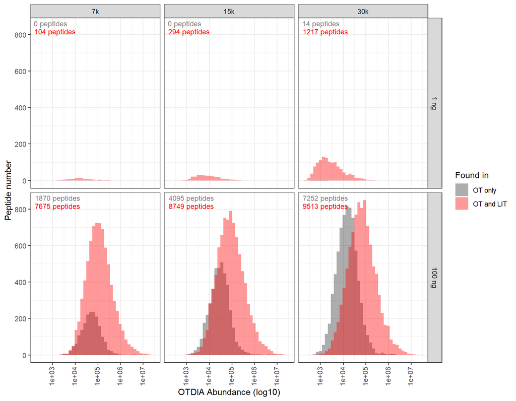

```r
LIT_in_OT_plot <- LIT_in_OT %>%
  ggplot(aes(x = mean_quantity, fill = in_LIT))+
  geom_histogram(bins = 40,
                 position = "identity",
                 alpha = 0.4)+
  scale_x_log10()+
  scale_fill_manual(values = c("grey20", "red"),
                    labels = c("OT only", "OT and LIT"))+
  labs(x = "OTDIA Abundance (log10)",
       y = "Peptide number",
       fill = "Found in")+
  theme(axis.text.x = element_text(angle = 90,
                                   vjust = 0.3)) +
  facet_grid(input ~ method)

labels1 <- c(paste0(sum(LIT_in_OT$method == "7k" &
                          LIT_in_OT$input == "1 ng" &
                          LIT_in_OT$in_LIT == FALSE),
                  " peptides"),
             paste0(sum(LIT_in_OT$method == "15k" &
                          LIT_in_OT$input == "1 ng" &
                          LIT_in_OT$in_LIT == FALSE),
                    " peptides"),
             paste0(sum(LIT_in_OT$method == "30k" &
                          LIT_in_OT$input == "1 ng" &
                          LIT_in_OT$in_LIT == FALSE),
                    " peptides"),
             paste0(sum(LIT_in_OT$method == "7k" &
                          LIT_in_OT$input == "100 ng" &
                          LIT_in_OT$in_LIT == FALSE),
                  " peptides"),
             paste0(sum(LIT_in_OT$method == "15k" &
                          LIT_in_OT$input == "100 ng" &
                          LIT_in_OT$in_LIT == FALSE),
                    " peptides"),
             paste0(sum(LIT_in_OT$method == "30k" &
                          LIT_in_OT$input == "100 ng" &
                          LIT_in_OT$in_LIT == FALSE),
                    " peptides"))

data_labels1 <-
  data.frame(method = as.factor(rep(c("7k", "15k", "30k"),2)),
             input = as.factor(c(rep("1 ng",3), rep("100 ng",3))),
             label = labels1,
             in_LIT = rep(FALSE, 6))

labels2 <- c(paste0(sum(LIT_in_OT$method == "7k" &
                          LIT_in_OT$input == "1 ng" &
                          LIT_in_OT$in_LIT == TRUE),
                  " peptides"),
             paste0(sum(LIT_in_OT$method == "15k" &
                          LIT_in_OT$input == "1 ng" &
                          LIT_in_OT$in_LIT == TRUE),
                    " peptides"),
             paste0(sum(LIT_in_OT$method == "30k" &
                          LIT_in_OT$input == "1 ng" &
                          LIT_in_OT$in_LIT == TRUE),
                    " peptides"),
             paste0(sum(LIT_in_OT$method == "7k" &
                          LIT_in_OT$input == "100 ng" &
                          LIT_in_OT$in_LIT == TRUE),
                  " peptides"),
             paste0(sum(LIT_in_OT$method == "15k" &
                          LIT_in_OT$input == "100 ng" &
                          LIT_in_OT$in_LIT == TRUE),
                    " peptides"),
             paste0(sum(LIT_in_OT$method == "30k" &
                          LIT_in_OT$input == "100 ng" &
                          LIT_in_OT$in_LIT == TRUE),
                    " peptides"))

data_labels2 <-
  data.frame(method = as.factor(rep(c("7k", "15k", "30k"),2)),
             input = as.factor(c(rep("1 ng",3), rep("100 ng",3))),
             label = labels1,
             in_LIT = rep(TRUE, 6))

LIT_in_OT_plot <- LIT_in_OT_plot +
  geom_text(x = -Inf, y = Inf,
            hjust = -0.1, vjust = 1.5,
            aes(label = labels1, group = NULL), data = data_labels1,
            size = 3.2,
            color = "grey50")+
  geom_text(x = -Inf, y = Inf,
            hjust = -0.1, vjust = 3,
            aes(label = labels2, group = NULL), data = data_labels2,
            size = 3.2,
            color = "red")
LIT_in_OT_plot
```

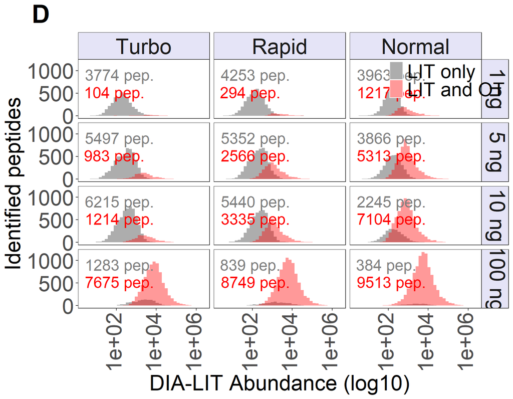

```r
OT_in_LIT_plot
```

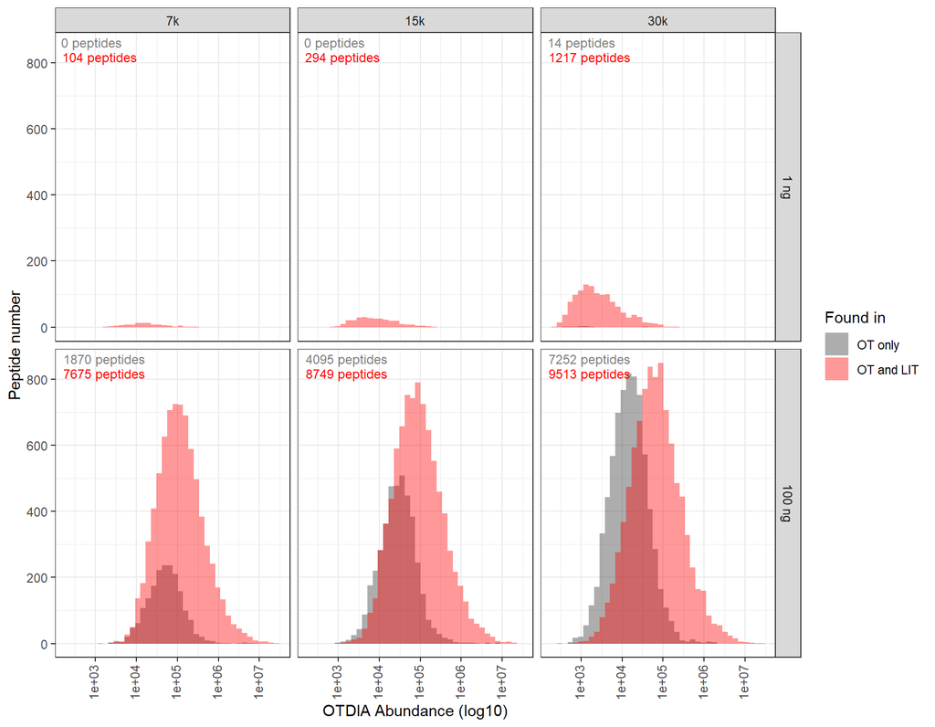

```r
LIT_in_OT_plot
```

For 1ng, only highly abundant peptides are found with OT For 100 ng, OT yields a higher number of peptides, regardless of the abundance but peptides with low abundance are less shared.

# 6 Peptide overlapping between different inputs

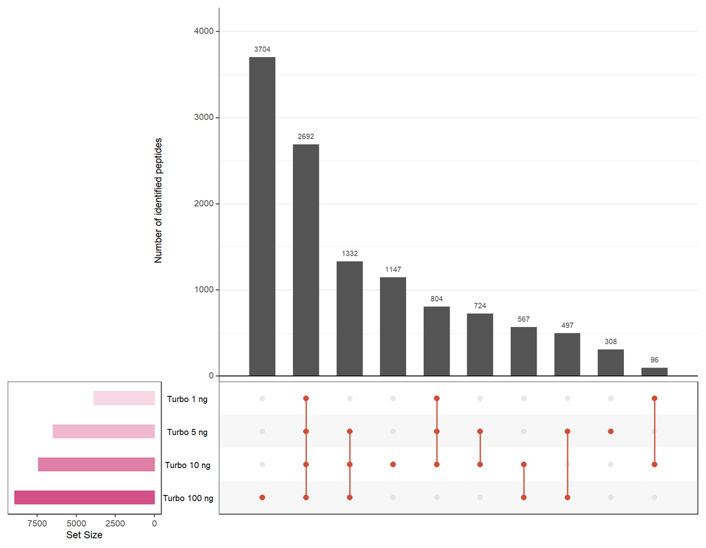

```r
Turbo_pep_list <-
  list('Turbo 1 ng' = LITDIA_Turbo_1_auto_filter$PEP.StrippedSequence,
       'Turbo 5 ng' = LITDIA_Turbo_5_auto_filter$PEP.StrippedSequence,
       'Turbo 10 ng' = LITDIA_Turbo_10_auto_filter$PEP.StrippedSequence,
       'Turbo 100 ng' = LITDIA_Turbo_100_auto_filter$PEP.StrippedSequence)

upset(fromList(Turbo_pep_list),
      sets = c('Turbo 100 ng', 'Turbo 10 ng', 'Turbo 5 ng', 'Turbo 1 ng'),
      order.by = "freq",
      keep.order = TRUE,
      mainbar.y.label = "Number of identified peptides",
      text.scale = 1.1,
      matrix.color = c("tomato3"),
      sets.bar.color = c("#D35087","#DF7FA7", "#EEB9CF","#F6D9E5" ),
      main.bar.color = "#555454",
      nintersects = 10)
```

# 7 CV

## 7.1 Compute CV

### 7.1.1 1 ng

LITDIA_Turbo auto

```r
LITDIA_Turbo_1_auto_CV <- LITDIA_Turbo_1_auto[,1:5] %>%
  pivot_longer(names_to = "Sample",
               values_to = "Quantity",
               -PEP.StrippedSequence) %>%
  group_by(PEP.StrippedSequence) %>%
  summarise(mean_quantity = mean(Quantity, na.rm = TRUE),
            sd_quantity = sd(Quantity, na.rm = TRUE)) %>%
  mutate(CV = sd_quantity/mean_quantity,
         method = "LITDIA_Turbo",
         input = "1 ng")
```

LITDIA_Rapid

```r
LITDIA_Rapid_1_CV <- LITDIA_Rapid_1[,1:5] %>%
  pivot_longer(names_to = "Sample",
               values_to = "Quantity",
               -PEP.StrippedSequence) %>%
  group_by(PEP.StrippedSequence) %>%
  summarise(mean_quantity = mean(Quantity, na.rm = TRUE),
            sd_quantity = sd(Quantity, na.rm = TRUE)) %>%
  mutate(CV = sd_quantity/mean_quantity,
         method = "LITDIA_Rapid",
         input = "1 ng")
```

LITDIA_Normal

```r
LITDIA_Normal_1_CV <- LITDIA_Normal_1[,1:5] %>%
  pivot_longer(names_to = "Sample",
               values_to = "Quantity",
               -PEP.StrippedSequence) %>%
  group_by(PEP.StrippedSequence) %>%
  summarise(mean_quantity = mean(Quantity, na.rm = TRUE),
            sd_quantity = sd(Quantity, na.rm = TRUE)) %>%
  mutate(CV = sd_quantity/mean_quantity,
         method = "LITDIA_Normal",
         input = "1 ng")
```

OTDIA_7k

```r
OTDIA_7k_1_CV <- OTDIA_7k_1[,1:5] %>%
  pivot_longer(names_to = "Sample",
               values_to = "Quantity",
               -PEP.StrippedSequence) %>%
  group_by(PEP.StrippedSequence) %>%
  summarise(mean_quantity = mean(Quantity, na.rm = TRUE),
            sd_quantity = sd(Quantity, na.rm = TRUE)) %>%
  mutate(CV = sd_quantity/mean_quantity,
         method = "OTDIA_7k",
         input = "1 ng")
```

OTDIA_15k

```r
OTDIA_15k_1_CV <- OTDIA_15k_1[,1:5] %>%
  pivot_longer(names_to = "Sample",
               values_to = "Quantity",
               -PEP.StrippedSequence) %>%
  group_by(PEP.StrippedSequence) %>%
  summarise(mean_quantity = mean(Quantity, na.rm = TRUE),
            sd_quantity = sd(Quantity, na.rm = TRUE)) %>%
  mutate(CV = sd_quantity/mean_quantity,
         method = "OTDIA_15k",
         input = "1 ng")
```

OTDIA_30k

```r
OTDIA_30k_1_CV <- OTDIA_30k_1[,1:5] %>%
  pivot_longer(names_to = "Sample",
               values_to = "Quantity",
               -PEP.StrippedSequence) %>%
  group_by(PEP.StrippedSequence) %>%
  summarise(mean_quantity = mean(Quantity, na.rm = TRUE),
            sd_quantity = sd(Quantity, na.rm = TRUE)) %>%
  mutate(CV = sd_quantity/mean_quantity,
         method = "OTDIA_30k",
         input = "1 ng")
```

### 7.1.2 5 ng

LITDIA_Turbo auto

```r
LITDIA_Turbo_5_auto_CV <- LITDIA_Turbo_5_auto[,1:5] %>%
  pivot_longer(names_to = "Sample",
               values_to = "Quantity",
               -PEP.StrippedSequence) %>%
  group_by(PEP.StrippedSequence) %>%
  summarise(mean_quantity = mean(Quantity, na.rm = TRUE),
            sd_quantity = sd(Quantity, na.rm = TRUE)) %>%
  mutate(CV = sd_quantity/mean_quantity,
         method = "LITDIA_Turbo",
         input = "5 ng")
```

LITDIA_Rapid

```r
LITDIA_Rapid_5_CV <- LITDIA_Rapid_5[,1:5] %>%
  pivot_longer(names_to = "Sample",
               values_to = "Quantity",
               -PEP.StrippedSequence) %>%
  group_by(PEP.StrippedSequence) %>%
  summarise(mean_quantity = mean(Quantity, na.rm = TRUE),
            sd_quantity = sd(Quantity, na.rm = TRUE)) %>%
  mutate(CV = sd_quantity/mean_quantity,
         method = "LITDIA_Rapid",
         input = "5 ng")
```

LITDIA_Normal

```r
LITDIA_Normal_5_CV <- LITDIA_Normal_5[,1:5] %>%
  pivot_longer(names_to = "Sample",
               values_to = "Quantity",
               -PEP.StrippedSequence) %>%
  group_by(PEP.StrippedSequence) %>%
  summarise(mean_quantity = mean(Quantity, na.rm = TRUE),
            sd_quantity = sd(Quantity, na.rm = TRUE)) %>%
  mutate(CV = sd_quantity/mean_quantity,
         method = "LITDIA_Normal",
         input = "5 ng")
```

OTDIA_7k

```r
OTDIA_7k_5_CV <- OTDIA_7k_5[,1:5] %>%
  pivot_longer(names_to = "Sample",
               values_to = "Quantity",
               -PEP.StrippedSequence) %>%
  group_by(PEP.StrippedSequence) %>%
  summarise(mean_quantity = mean(Quantity, na.rm = TRUE),
            sd_quantity = sd(Quantity, na.rm = TRUE)) %>%
  mutate(CV = sd_quantity/mean_quantity,
         method = "OTDIA_7k",
         input = "5 ng")
```

OTDIA_15k

```r
OTDIA_15k_5_CV <- OTDIA_15k_5[,1:5] %>%
  pivot_longer(names_to = "Sample",
               values_to = "Quantity",
               -PEP.StrippedSequence) %>%
  group_by(PEP.StrippedSequence) %>%
  summarise(mean_quantity = mean(Quantity, na.rm = TRUE),
            sd_quantity = sd(Quantity, na.rm = TRUE)) %>%
  mutate(CV = sd_quantity/mean_quantity,
         method = "OTDIA_15k",
         input = "5 ng")
```

OTDIA_30k

```r
OTDIA_30k_5_CV <- OTDIA_30k_5[,1:5] %>%
  pivot_longer(names_to = "Sample",
               values_to = "Quantity",
               -PEP.StrippedSequence) %>%
  group_by(PEP.StrippedSequence) %>%
  summarise(mean_quantity = mean(Quantity, na.rm = TRUE),
            sd_quantity = sd(Quantity, na.rm = TRUE)) %>%
  mutate(CV = sd_quantity/mean_quantity,
         method = "OTDIA_30k",
         input = "5 ng")
```

### 7.1.3 10 ng

LITDIA_Turbo auto

```r
LITDIA_Turbo_10_auto_CV <- LITDIA_Turbo_10_auto[,1:5] %>%
  pivot_longer(names_to = "Sample",
               values_to = "Quantity",
               -PEP.StrippedSequence) %>%
  group_by(PEP.StrippedSequence) %>%
  summarise(mean_quantity = mean(Quantity, na.rm = TRUE),
            sd_quantity = sd(Quantity, na.rm = TRUE)) %>%
  mutate(CV = sd_quantity/mean_quantity,
         method = "LITDIA_Turbo",
         input = "10 ng")
```

LITDIA_Rapid

```r
LITDIA_Rapid_10_CV <- LITDIA_Rapid_10[,1:5] %>%
  pivot_longer(names_to = "Sample",
               values_to = "Quantity",
               -PEP.StrippedSequence) %>%
  group_by(PEP.StrippedSequence) %>%
  summarise(mean_quantity = mean(Quantity, na.rm = TRUE),
            sd_quantity = sd(Quantity, na.rm = TRUE)) %>%
  mutate(CV = sd_quantity/mean_quantity,
         method = "LITDIA_Rapid",
         input = "10 ng")
```

LITDIA_Normal

```r
LITDIA_Normal_10_CV <- LITDIA_Normal_10[,1:5] %>%
  pivot_longer(names_to = "Sample",
               values_to = "Quantity",
               -PEP.StrippedSequence) %>%
  group_by(PEP.StrippedSequence) %>%
  summarise(mean_quantity = mean(Quantity, na.rm = TRUE),
            sd_quantity = sd(Quantity, na.rm = TRUE)) %>%
  mutate(CV = sd_quantity/mean_quantity,
         method = "LITDIA_Normal",
         input = "10 ng")
```

OTDIA_7k

```r
OTDIA_7k_10_CV <- OTDIA_7k_10[,1:5] %>%
  pivot_longer(names_to = "Sample",
               values_to = "Quantity",
               -PEP.StrippedSequence) %>%
  group_by(PEP.StrippedSequence) %>%
  summarise(mean_quantity = mean(Quantity, na.rm = TRUE),
            sd_quantity = sd(Quantity, na.rm = TRUE)) %>%
  mutate(CV = sd_quantity/mean_quantity,
         method = "OTDIA_7k",
         input = "10 ng")
```

OTDIA_15k

```r
OTDIA_15k_10_CV <- OTDIA_15k_10[,1:5] %>%
  pivot_longer(names_to = "Sample",
               values_to = "Quantity",
               -PEP.StrippedSequence) %>%
  group_by(PEP.StrippedSequence) %>%
  summarise(mean_quantity = mean(Quantity, na.rm = TRUE),
            sd_quantity = sd(Quantity, na.rm = TRUE)) %>%
  mutate(CV = sd_quantity/mean_quantity,
         method = "OTDIA_15k",
         input = "10 ng")
```

OTDIA_30k

```r
OTDIA_30k_10_CV <- OTDIA_30k_10[,1:5] %>%
  pivot_longer(names_to = "Sample",
               values_to = "Quantity",
               -PEP.StrippedSequence) %>%
  group_by(PEP.StrippedSequence) %>%
  summarise(mean_quantity = mean(Quantity, na.rm = TRUE),
            sd_quantity = sd(Quantity, na.rm = TRUE)) %>%
  mutate(CV = sd_quantity/mean_quantity,
         method = "OTDIA_30k",
         input = "10 ng")
```

### 7.1.4 100 ng

LITDIA_Turbo

```r
LITDIA_Turbo_100_auto_CV <- LITDIA_Turbo_100_auto[,1:5] %>%
  pivot_longer(names_to = "Sample",
               values_to = "Quantity",
               -PEP.StrippedSequence) %>%
  group_by(PEP.StrippedSequence) %>%
  summarise(mean_quantity = mean(Quantity, na.rm = TRUE),
            sd_quantity = sd(Quantity, na.rm = TRUE)) %>%
  mutate(CV = sd_quantity/mean_quantity,
         method = "LITDIA_Turbo",
         input = "100 ng")
```

LITDIA_Rapid

```r
LITDIA_Rapid_100_CV <- LITDIA_Rapid_100[,1:5] %>%
  pivot_longer(names_to = "Sample",
               values_to = "Quantity",
               -PEP.StrippedSequence) %>%
  group_by(PEP.StrippedSequence) %>%
  summarise(mean_quantity = mean(Quantity, na.rm = TRUE),
            sd_quantity = sd(Quantity, na.rm = TRUE)) %>%
  mutate(CV = sd_quantity/mean_quantity,
         method = "LITDIA_Rapid",
         input = "100 ng")
```

LITDIA_Normal

```r
LITDIA_Normal_100_CV <- LITDIA_Normal_100[,1:5] %>%
  pivot_longer(names_to = "Sample",
               values_to = "Quantity",
               -PEP.StrippedSequence) %>%
  group_by(PEP.StrippedSequence) %>%
  summarise(mean_quantity = mean(Quantity, na.rm = TRUE),
            sd_quantity = sd(Quantity, na.rm = TRUE)) %>%
  mutate(CV = sd_quantity/mean_quantity,
         method = "LITDIA_Normal",
         input = "100 ng")
```

OTDIA_7k

```r
OTDIA_7k_100_CV <- OTDIA_7k_100[,1:5] %>%
  pivot_longer(names_to = "Sample",
               values_to = "Quantity",
               -PEP.StrippedSequence) %>%
  group_by(PEP.StrippedSequence) %>%
  summarise(mean_quantity = mean(Quantity, na.rm = TRUE),
            sd_quantity = sd(Quantity, na.rm = TRUE)) %>%
  mutate(CV = sd_quantity/mean_quantity,
         method = "OTDIA_7k",
         input = "100 ng")
```

OTDIA_15k

```r
OTDIA_15k_100_CV <- OTDIA_15k_100[,1:5] %>%
  pivot_longer(names_to = "Sample",
               values_to = "Quantity",
               -PEP.StrippedSequence) %>%
  group_by(PEP.StrippedSequence) %>%
  summarise(mean_quantity = mean(Quantity, na.rm = TRUE),
            sd_quantity = sd(Quantity, na.rm = TRUE)) %>%
  mutate(CV = sd_quantity/mean_quantity,
         method = "OTDIA_15k",
         input = "100 ng")
```

OTDIA_30k

```r
OTDIA_30k_100_CV <- OTDIA_30k_100[,1:5] %>%
  pivot_longer(names_to = "Sample",
               values_to = "Quantity",
               -PEP.StrippedSequence) %>%
  group_by(PEP.StrippedSequence) %>%
  summarise(mean_quantity = mean(Quantity, na.rm = TRUE),
            sd_quantity = sd(Quantity, na.rm = TRUE)) %>%
  mutate(CV = sd_quantity/mean_quantity,
         method = "OTDIA_30k",
         input = "100 ng")
```

## 7.2 Join

```r
CV_joined <-
  rbind(LITDIA_Turbo_1_auto_CV, LITDIA_Rapid_1_CV, LITDIA_Normal_1_CV,
      OTDIA_7k_1_CV, OTDIA_15k_1_CV, OTDIA_30k_1_CV,
      LITDIA_Turbo_5_auto_CV, LITDIA_Rapid_5_CV, LITDIA_Normal_5_CV,
      OTDIA_7k_5_CV, OTDIA_15k_5_CV, OTDIA_30k_5_CV,
      LITDIA_Turbo_10_auto_CV, LITDIA_Rapid_10_CV, LITDIA_Normal_10_CV,
      OTDIA_7k_10_CV, OTDIA_15k_10_CV, OTDIA_30k_10_CV,
      LITDIA_Turbo_100_auto_CV, LITDIA_Rapid_100_CV, LITDIA_Normal_100_CV,
      OTDIA_7k_100_CV, OTDIA_15k_100_CV, OTDIA_30k_100_CV)

CV_joined$input <- factor(CV_joined$input, levels = unique(CV_joined$input))
```

## 7.3 Plot CV

```r
CV_joined$method <- factor(CV_joined$method, levels = unique(CV_joined$method))
CV_joined$indiv <- paste(CV_joined$method, CV_joined$input, sep = " ")
CV_joined$method %>% table()
```

```
## .
##  LITDIA_Turbo  LITDIA_Rapid LITDIA_Normal      OTDIA_7k     OTDIA_15k
##         27124         31156         34020         12130         19463
##     OTDIA_30k
##         33600
```

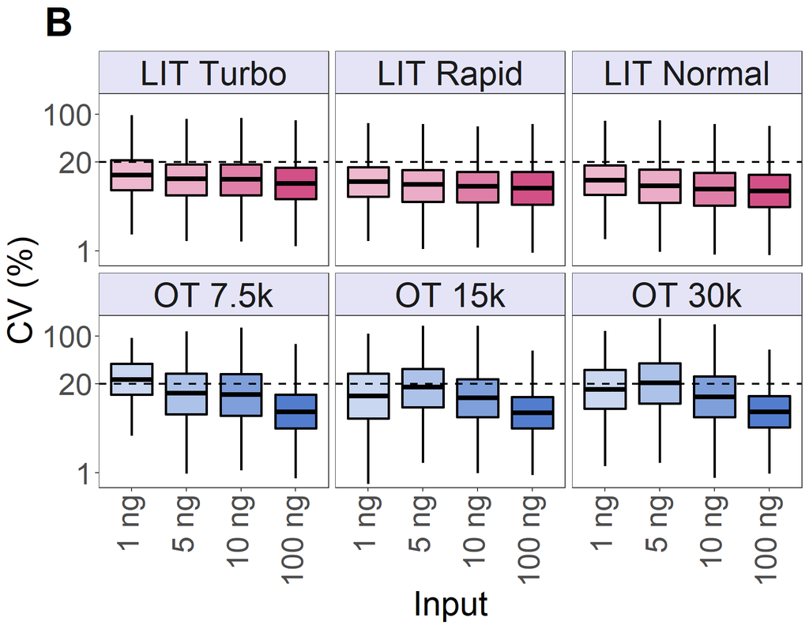

```r
lim <-
  c(boxplot.stats(log10(CV_joined[CV_joined$method ==
                                    "LITDIA_Turbo",]$CV*100))$stats[c(1,5)],
    boxplot.stats(log10(CV_joined[CV_joined$method ==
                                    "LITDIA_Rapid",]$CV*100))$stats[c(1,5)],
    boxplot.stats(log10(CV_joined[CV_joined$method ==
                                    "LITDIA_Normal",]$CV*100))$stats[c(1,5)],
    boxplot.stats(log10(CV_joined[CV_joined$method ==
                                    "OTDIA_7k",]$CV*100))$stats[c(1,5)],
    boxplot.stats(log10(CV_joined[CV_joined$method ==
                                    "OTDIA_15k",]$CV*100))$stats[c(1,5)],
    boxplot.stats(log10(CV_joined[CV_joined$method ==
                                    "OTDIA_30k",]$CV*100))$stats[c(1,5)])
lim <- c(min(lim), max(lim))

CV_plot <- CV_joined %>%
  ggplot(aes(x = as.factor(input),
             y = CV*100,
             fill = as.factor(indiv)))+
  geom_boxplot(outlier.shape = NA,
               color = "black",
               size = 0.9)+
  scale_fill_manual(values = c(rep(teera_palette[c(1: 4)], 3),
                               rep(teera_palette[c(5: 8)], 3))) +
  scale_y_log10(breaks = c(1, 20, 100))+
  geom_hline(yintercept = 20,
             linetype = "dashed",
             size = 0.8)+
  labs(x = "Input",
       y = "CV (%)",
       title = "B")+
  theme(legend.position = "none",
        panel.grid = element_blank(),
        axis.title = element_text(size = 27),
        axis.text = element_text(size = 24),
        axis.text.x = element_text(angle = 90, vjust = 0.3, hjust = 1),
        strip.text.x = element_text(size = 27),
        strip.background = element_rect(fill = "#E5E4F7"),
        plot.title = element_text(size = 32, face = "bold",
                                  hjust = -0.08))+
  facet_wrap(~method, labeller = labeller(method =
    c("LITDIA_Turbo" = "LIT Turbo",
      "LITDIA_Rapid" = "LIT Rapid",
      "LITDIA_Normal" = "LIT Normal",
      "OTDIA_7k" = "OT 7.5k",
      "OTDIA_15k" = "OT 15k",
      "OTDIA_30k" = "OT 30k")))+
  coord_cartesian(ylim = 10^(lim))


CV_plot
```

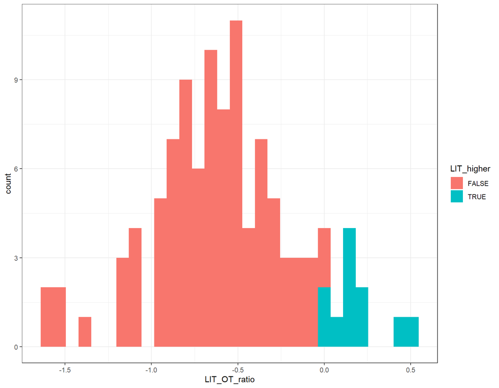

```r
inner_join(LITDIA_Turbo_1_auto_CV[, c(1, 4)],
           OTDIA_7k_1_CV[, c(1, 4)],
           by = "PEP.StrippedSequence") %>%
  mutate(LIT_OT_ratio = log10(CV.x/CV.y)) %>%
  mutate(LIT_higher = LIT_OT_ratio >= 0) %>%
  ggplot(aes(x = LIT_OT_ratio,
             fill = LIT_higher)) +
  geom_histogram()
```

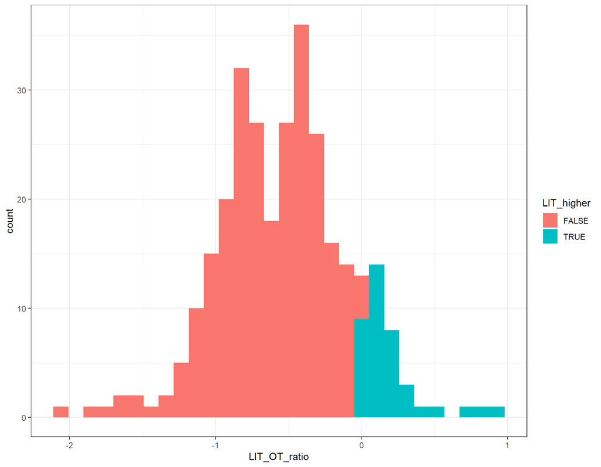

```r
inner_join(LITDIA_Rapid_1_CV[, c(1, 4)],
           OTDIA_15k_1_CV[, c(1, 4)],
           by = "PEP.StrippedSequence") %>%
  mutate(LIT_OT_ratio = log10(CV.x/CV.y)) %>%
  mutate(LIT_higher = LIT_OT_ratio >= 0) %>%
  ggplot(aes(x = LIT_OT_ratio,
             fill = LIT_higher)) +
  geom_histogram()
```

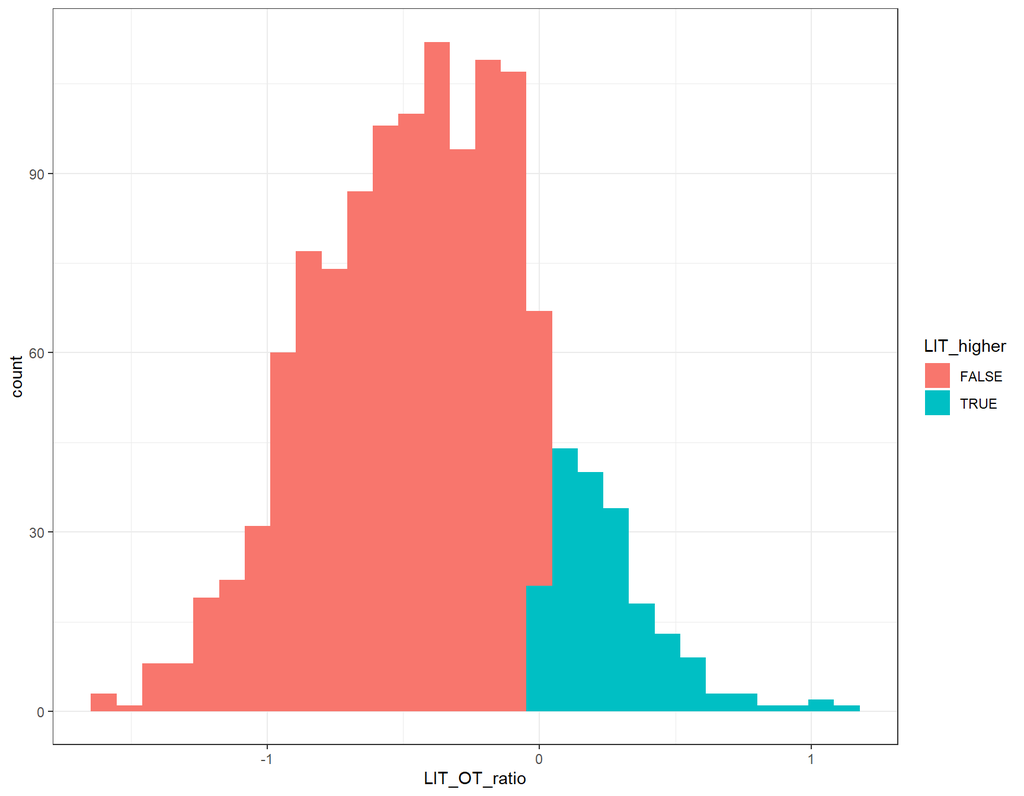

```r
inner_join(LITDIA_Normal_1_CV[, c(1, 4)],
           OTDIA_30k_1_CV[, c(1, 4)],
           by = "PEP.StrippedSequence") %>%
  mutate(LIT_OT_ratio = log10(CV.x/CV.y)) %>%
  mutate(LIT_higher = LIT_OT_ratio >= 0) %>%
  ggplot(aes(x = LIT_OT_ratio,
             fill = LIT_higher)) +
  geom_histogram()
```

# 8 Identified peptides

```r
sum(!is.na(LITDIA_Turbo_1[, 2]))
```

```
## [1] 5052
```

```r
sum(!is.na(LITDIA_Turbo_1[, 3]))
```

```
## [1] 0
```

```r
sum(!is.na(LITDIA_Turbo_1[, 4]))
```

```
## [1] 5052
```

```r
sum(!is.na(LITDIA_Turbo_1[, 5]))
```

```
## [1] 5052
```

```r
id_LITDIA_Turbo_1_auto <- id_LITDIA_Turbo_5_auto <- id_LITDIA_Turbo_10_auto <- id_LITDIA_Turbo_100_auto <-
  id_LITDIA_Rapid_1 <- id_LITDIA_Rapid_5 <- id_LITDIA_Rapid_10 <- id_LITDIA_Rapid_100 <-
  id_LITDIA_Normal_1 <- id_LITDIA_Normal_5 <- id_LITDIA_Normal_10 <- id_LITDIA_Normal_100 <-
  id_OTDIA_7k_1 <- id_OTDIA_7k_5 <- id_OTDIA_7k_10 <- id_OTDIA_7k_100 <-
  id_OTDIA_15k_1 <- id_OTDIA_15k_5 <- id_OTDIA_15k_10 <- id_OTDIA_15k_100 <-
  id_OTDIA_30k_1 <- id_OTDIA_30k_5 <- id_OTDIA_30k_10 <- id_OTDIA_30k_100 <- rep(NA, 4)
```

## 8.1 1 ng

OT 7.5k DIA

```r
for(i in 2:5){
  id_OTDIA_7k_1[i-1] <- sum(!is.na(OTDIA_7k_1[, i]))}
```

OT 15k DIA

```r
for(i in 2:5){
  id_OTDIA_15k_1[i-1] <- sum(!is.na(OTDIA_15k_1[, i]))}
```

OT 30k DIA

```r
for(i in 2:5){
  id_OTDIA_30k_1[i-1] <- sum(!is.na(OTDIA_30k_1[, i]))}
```

LIT Turbo DIA auto

```r
for(i in 2:5){
id_LITDIA_Turbo_1_auto[i-1] <- sum(!is.na(LITDIA_Turbo_1_auto[, i]))}
```

LIT Rapid DIA

```r
for(i in 2:5){
id_LITDIA_Rapid_1[i-1] <- sum(!is.na(LITDIA_Rapid_1[, i]))}
```

LIT Normal DIA

```r
for(i in 2:5){
id_LITDIA_Normal_1[i-1] <- sum(!is.na(LITDIA_Normal_1[, i]))}
```

## 8.2 5 ng

OT 7.5k DIA

```r
for(i in 2:5){
  id_OTDIA_7k_5[i-1] <- sum(!is.na(OTDIA_7k_5[, i]))}
```

OT 15k DIA

```r
for(i in 2:5){
  id_OTDIA_15k_5[i-1] <- sum(!is.na(OTDIA_15k_5[, i]))}
```

OT 30k DIA

```r
for(i in 2:5){
  id_OTDIA_30k_5[i-1] <- sum(!is.na(OTDIA_30k_5[, i]))}
```

LIT Turbo DIA auto

```r
for(i in 2:5){
id_LITDIA_Turbo_5_auto[i-1] <- sum(!is.na(LITDIA_Turbo_5_auto[, i]))}
```

LIT Rapid DIA

```r
for(i in 2:5){
id_LITDIA_Rapid_5[i-1] <- sum(!is.na(LITDIA_Rapid_5[, i]))}
```

LIT Normal DIA

```r
for(i in 2:5){
id_LITDIA_Normal_5[i-1] <- sum(!is.na(LITDIA_Normal_5[, i]))}
```

## 8.3 10 ng

OT 7.5k DIA

```r
for(i in 2:5){
  id_OTDIA_7k_10[i-1] <- sum(!is.na(OTDIA_7k_10[, i]))}
```

OT 15k DIA

```r
for(i in 2:5){
  id_OTDIA_15k_10[i-1] <- sum(!is.na(OTDIA_15k_10[, i]))}
```

OT 30k DIA

```r
for(i in 2:5){
  id_OTDIA_30k_10[i-1] <- sum(!is.na(OTDIA_30k_10[, i]))}
```

LIT Turbo DIA auto

```r
for(i in 2:5){
id_LITDIA_Turbo_10_auto[i-1] <- sum(!is.na(LITDIA_Turbo_10_auto[, i]))}
```

LIT Rapid DIA

```r
for(i in 2:5){
id_LITDIA_Rapid_10[i-1] <- sum(!is.na(LITDIA_Rapid_10[, i]))}
```

LIT Normal DIA

```r
for(i in 2:5){
id_LITDIA_Normal_10[i-1] <- sum(!is.na(LITDIA_Normal_10[, i]))}
```

## 8.4 100 ng

OT 7.5k DIA

```r
for(i in 2:5){
  id_OTDIA_7k_100[i-1] <- sum(!is.na(OTDIA_7k_100[, i]))}
```

OT 15k DIA

```r
for(i in 2:5){
  id_OTDIA_15k_100[i-1] <- sum(!is.na(OTDIA_15k_100[, i]))}
```

OT 30k DIA

```r
for(i in 2:5){
  id_OTDIA_30k_100[i-1] <- sum(!is.na(OTDIA_30k_100[, i]))}
```

LIT Turbo DIA auto

```r
for(i in 2:5){
id_LITDIA_Turbo_100_auto[i-1] <- sum(!is.na(LITDIA_Turbo_100_auto[, i]))}
```

LIT Rapid DIA

```r
for(i in 2:5){
id_LITDIA_Rapid_100[i-1] <- sum(!is.na(LITDIA_Rapid_100[, i]))}
```

LIT Normal DIA

```r
for(i in 2:5){
id_LITDIA_Normal_100[i-1] <- sum(!is.na(LITDIA_Normal_100[, i]))}
```

## 8.5 Join

```r
id_pep <- data.frame(method = rep(c(rep("OT 7.5k", 4), rep("OT 15k", 4), rep("OT 30k", 4),
                                    rep("LIT Turbo", 4), rep("LIT Rapid", 4), rep("LIT Normal", 4)), 4),
           replicate = rep(1:4, 24),
           id = c(id_OTDIA_7k_1, id_OTDIA_15k_1, id_OTDIA_30k_1,
                  id_LITDIA_Turbo_1_auto, id_LITDIA_Rapid_1, id_LITDIA_Normal_1,
                  id_OTDIA_7k_5, id_OTDIA_15k_5, id_OTDIA_30k_5,
                  id_LITDIA_Turbo_5_auto, id_LITDIA_Rapid_5, id_LITDIA_Normal_5,
                  id_OTDIA_7k_10, id_OTDIA_15k_10, id_OTDIA_30k_10,
                  id_LITDIA_Turbo_10_auto, id_LITDIA_Rapid_10, id_LITDIA_Normal_10,
                  id_OTDIA_7k_100, id_OTDIA_15k_100, id_OTDIA_30k_100,
                  id_LITDIA_Turbo_100_auto, id_LITDIA_Rapid_100, id_LITDIA_Normal_100),
           input = c(rep("1 ng", 24), rep("5 ng", 24), rep("10 ng", 24), rep("100 ng", 24)))

id_pep$method <- factor(id_pep$method, levels = unique(id_pep$method))
id_pep$input <- factor(id_pep$input, levels = unique(id_pep$input))
```

## 8.6 plot

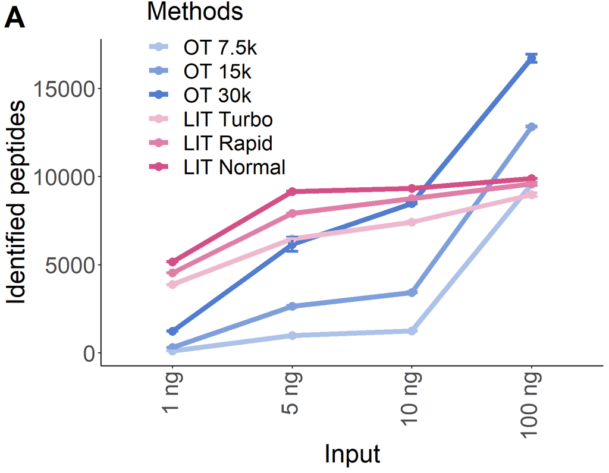

```r
id_plot <- id_pep %>%
  group_by(method, input) %>%
  summarise(mean_id = mean(id),
            sd_id = sd(id))%>%
  ggplot(aes(x = input, y = mean_id, group = method, color = method))+
  theme_classic2()+
  geom_line(size = 2.5)+
  geom_point(size = 4)+
  scale_color_manual(values = c("#ADC2E8", "#7F9FDB", "#527DCE", "#EEB9CF", "#DF7FA7", "#D35087"))+
  geom_errorbar(aes(ymin = mean_id - sd_id,
                         ymax = mean_id + sd_id),
                    width = 0.1,
                    size = 1.5)+
  labs(color = "Methods",
       x = "Input",
       y = "Identified peptides",
       title = "A")+
  theme(legend.position = c(0.23, 0.85),
        legend.background = element_blank(),
        legend.title = element_text(size = 27),
        legend.text = element_text(size = 22),
        axis.text = element_text(size = 24),
        axis.title = element_text(size = 27),
        legend.key.size = unit(0.9, "cm"),
        plot.title = element_text(size = 32, face = "bold",
                                  hjust = -0.2),
        axis.text.x = element_text(angle = 90, vjust = 0.3, hjust = 1))

id_plot
```

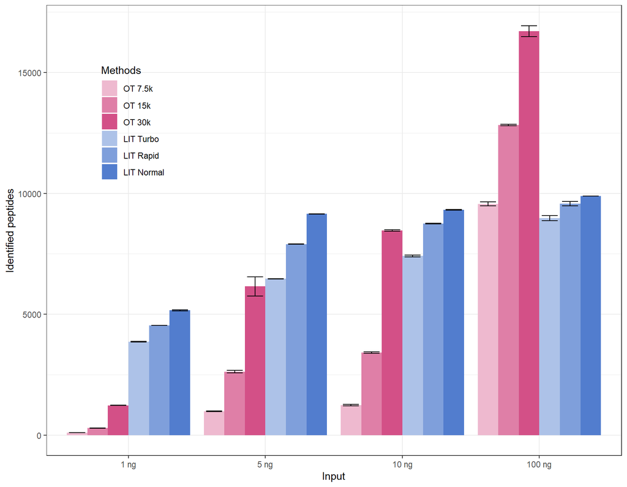

```r
id_pep %>%
  group_by(method, input) %>%
  summarise(mean_id = mean(id),
            sd_id = sd(id))%>%
  ggplot(aes(x = input, y = mean_id, fill = method))+
  geom_col(position = position_dodge())+
  scale_fill_manual(values = c("#EEB9CF", "#DF7FA7", "#D35087", "#ADC2E8", "#7F9FDB", "#527DCE"))+
  geom_errorbar(aes(ymin = mean_id - sd_id,
                    ymax = mean_id + sd_id),
                width = 0.7,
                size = 0.5,
                position = position_dodge(0.9))+
  labs(fill = "Methods",
       x = "Input",
       y = "Identified peptides")+
  theme(legend.position = c(0.15, 0.74),
        legend.background = element_blank())
```

# 9 Figure 1

```r
temp <- id_plot +  CV_plot + plot_layout(widths = c(1, 2))
temp2 <- plot_spacer() + corr_plot + plot_spacer() + plot_layout(widths = c(1, 10, 1))
temp3 <- plot_spacer() + OT_in_LIT_plot + plot_spacer() + plot_layout(widths = c(1, 10, 1))
fig1 <- temp/temp2/temp3 + plot_layout(heights = c(0.8, 1, 1))
```

# 10 Windowing scheme

## 10.1 Load data

### 10.1.1 1 ng

```r
#34w
LITDIA_Normal_34w_1 <- read.csv2(paste0(lit_path, "20220509_LIT_Normal_DIA_1ng_40SPD_whisper100_1CV_auto_34w.csv"))
#45w
LITDIA_Normal_45w_1 <- read.csv2(paste0(lit_path, "20220509_LIT_Normal_DIA_1ng_40SPD_whisper100_1CV_auto_45w.csv"))
```

### 10.1.2 100 ng

```r
#34w
LITDIA_Normal_34w_100 <- read.csv2(paste0(lit_path, "20220509_LIT_Normal_DIA_100ng_40SPD_whisper100_1CV_auto_34w.csv"))
#45w
LITDIA_Normal_45w_100 <- read.csv2(paste0(lit_path, "20220509_LIT_Normal_DIA_100ng_40SPD_whisper100_1CV_auto_45w.csv"))
```

## 10.2 Remove peptides found in less than 3 replicates

### 10.2.1 1 ng

```r
LITDIA_Normal_34w_1 <-  filter_pep(LITDIA_Normal_34w_1)
LITDIA_Normal_34w_1_filter <- LITDIA_Normal_34w_1[LITDIA_Normal_34w_1$filtered == FALSE, ]
LITDIA_Normal_45w_1 <-  filter_pep(LITDIA_Normal_45w_1)
LITDIA_Normal_45w_1_filter <- LITDIA_Normal_45w_1[LITDIA_Normal_45w_1$filtered == FALSE, ]
```

### 10.2.2 100 ng

```r
LITDIA_Normal_34w_100 <-  filter_pep(LITDIA_Normal_34w_100)
LITDIA_Normal_34w_100_filter <- LITDIA_Normal_34w_100[LITDIA_Normal_34w_100$filtered == FALSE, ]
LITDIA_Normal_45w_100 <-  filter_pep(LITDIA_Normal_45w_100)
LITDIA_Normal_45w_100_filter <- LITDIA_Normal_45w_100[LITDIA_Normal_45w_100$filtered == FALSE, ]
```

## 10.3 id

```r
id_LITDIA_Normal_34w_1 <- id_LITDIA_Normal_45w_1 <-
  id_LITDIA_Normal_34w_100 <- id_LITDIA_Normal_45w_100 <- rep(NA, 4)
```

### 10.3.1 1 ng

34w

```r
for(i in 2:5){
  id_LITDIA_Normal_34w_1[i-1] <- sum(!is.na(LITDIA_Normal_34w_1[, i]))}
```

45w

```r
for(i in 2:5){
  id_LITDIA_Normal_45w_1[i-1] <- sum(!is.na(LITDIA_Normal_45w_1[, i]))}
```

### 10.3.2 100 ng

34w

```r
for(i in 2:5){
  id_LITDIA_Normal_34w_100[i-1] <- sum(!is.na(LITDIA_Normal_34w_100[, i]))}
```

45w

```r
for(i in 2:5){
  id_LITDIA_Normal_45w_100[i-1] <- sum(!is.na(LITDIA_Normal_45w_100[, i]))}
```

### 10.3.3 Join

```r
id_win <- data.frame(method = rep(c(rep("34w", 4), rep("40w", 4),
                                    rep("45w", 4)),2),
           replicate = rep(1:4, 6),
           id = c(id_LITDIA_Normal_34w_1, id_LITDIA_Normal_1, id_LITDIA_Normal_45w_1,
                  id_LITDIA_Normal_34w_100, id_LITDIA_Normal_100, id_LITDIA_Normal_45w_100),
           input = c(rep("1 ng", 12), rep("100 ng", 12)))

id_win$method <- factor(id_win$method, levels = unique(id_win$method))
id_win$input <- factor(id_win$input, levels = unique(id_win$input))
```

### 10.3.4 plot

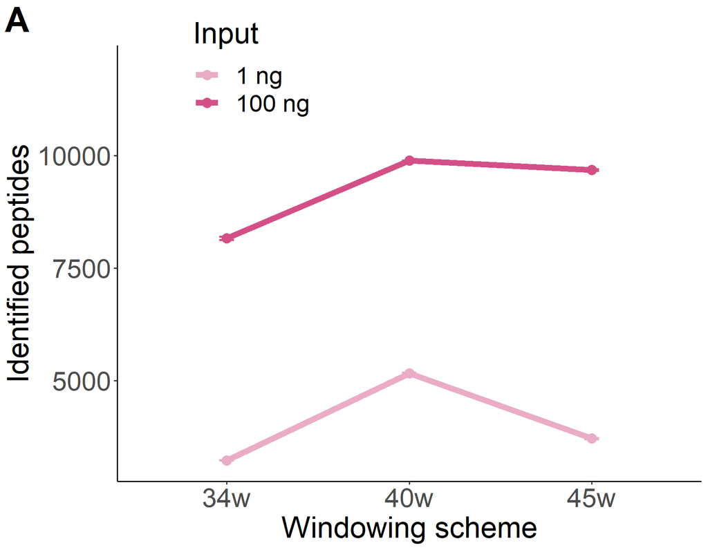

```r
id_win_plot <- id_win %>%
  group_by(method, input) %>%
  summarise(mean_id = mean(id),
            sd_id = sd(id))%>%
  ggplot(aes(x = method, y = mean_id, group = input, color = input))+
  theme_classic2()+
  geom_line(size = 2.5)+
  geom_point(size = 4)+
  scale_color_manual(values = c("#EAACC6","#D35087"))+
  scale_y_continuous(limits = c(3200, 12000))+
  geom_errorbar(aes(ymin = mean_id - sd_id,
                         ymax = mean_id + sd_id),
                    width = 0.08,
                    size = 1)+
  labs(color = "Input",
       x = "Windowing scheme",
       y = "Identified peptides",
       title = "A")+
  theme(legend.position = c(0.23, 0.95),
        legend.background = element_blank(),
        legend.title = element_text(size = 27),
        legend.text = element_text(size = 22),
        axis.text = element_text(size = 24),
        axis.title = element_text(size = 27),
        legend.key.size = unit(0.9, "cm"),
        plot.title = element_text(size = 32, face = "bold",
                                  hjust = -0.2))

id_win_plot
```

## 10.4 CV

## 10.5 Compute CV

### 10.5.1 1 ng

LITDIA Normal 34w

```r
LITDIA_Normal_34w_1_CV <- LITDIA_Normal_34w_1[,1:5] %>%
  pivot_longer(names_to = "Sample",
               values_to = "Quantity",
               -PEP.StrippedSequence) %>%
  group_by(PEP.StrippedSequence) %>%
  summarise(mean_quantity = mean(Quantity, na.rm = TRUE),
            sd_quantity = sd(Quantity, na.rm = TRUE)) %>%
  mutate(CV = sd_quantity/mean_quantity,
         method = "34w",
         input = "1 ng")
```

LITDIA Normal 45w

```r
LITDIA_Normal_45w_1_CV <- LITDIA_Normal_45w_1[,1:5] %>%
  pivot_longer(names_to = "Sample",
               values_to = "Quantity",
               -PEP.StrippedSequence) %>%
  group_by(PEP.StrippedSequence) %>%
  summarise(mean_quantity = mean(Quantity, na.rm = TRUE),
            sd_quantity = sd(Quantity, na.rm = TRUE)) %>%
  mutate(CV = sd_quantity/mean_quantity,
         method = "45w",
         input = "1 ng")
```

### 10.5.2 100 ng

LITDIA Normal 34w

```r
LITDIA_Normal_34w_100_CV <- LITDIA_Normal_34w_100[,1:5] %>%
  pivot_longer(names_to = "Sample",
               values_to = "Quantity",
               -PEP.StrippedSequence) %>%
  group_by(PEP.StrippedSequence) %>%
  summarise(mean_quantity = mean(Quantity, na.rm = TRUE),
            sd_quantity = sd(Quantity, na.rm = TRUE)) %>%
  mutate(CV = sd_quantity/mean_quantity,
         method = "34w",
         input = "100 ng")
```

LITDIA Normal 45w

```r
LITDIA_Normal_45w_100_CV <- LITDIA_Normal_45w_100[,1:5] %>%
  pivot_longer(names_to = "Sample",
               values_to = "Quantity",
               -PEP.StrippedSequence) %>%
  group_by(PEP.StrippedSequence) %>%
  summarise(mean_quantity = mean(Quantity, na.rm = TRUE),
            sd_quantity = sd(Quantity, na.rm = TRUE)) %>%
  mutate(CV = sd_quantity/mean_quantity,
         method = "45w",
         input = "100 ng")
```

### 10.5.3 Join

```r
CV_win_joined <-
  rbind(LITDIA_Normal_34w_1_CV, LITDIA_Normal_1_CV, LITDIA_Normal_45w_1_CV,
        LITDIA_Normal_34w_100_CV, LITDIA_Normal_100_CV, LITDIA_Normal_45w_100_CV)

CV_win_joined$input <- factor(CV_win_joined$input, levels = unique(CV_win_joined$input))
```

### 10.5.4 Plot

```r
CV_win_joined$method <- factor(CV_win_joined$method, levels = unique(CV_win_joined$method))
CV_win_joined$indiv <- paste(CV_win_joined$method, CV_win_joined$input, sep = " ")

levels(CV_win_joined$method)
```

```
## [1] "34w"           "LITDIA_Normal" "45w"
```

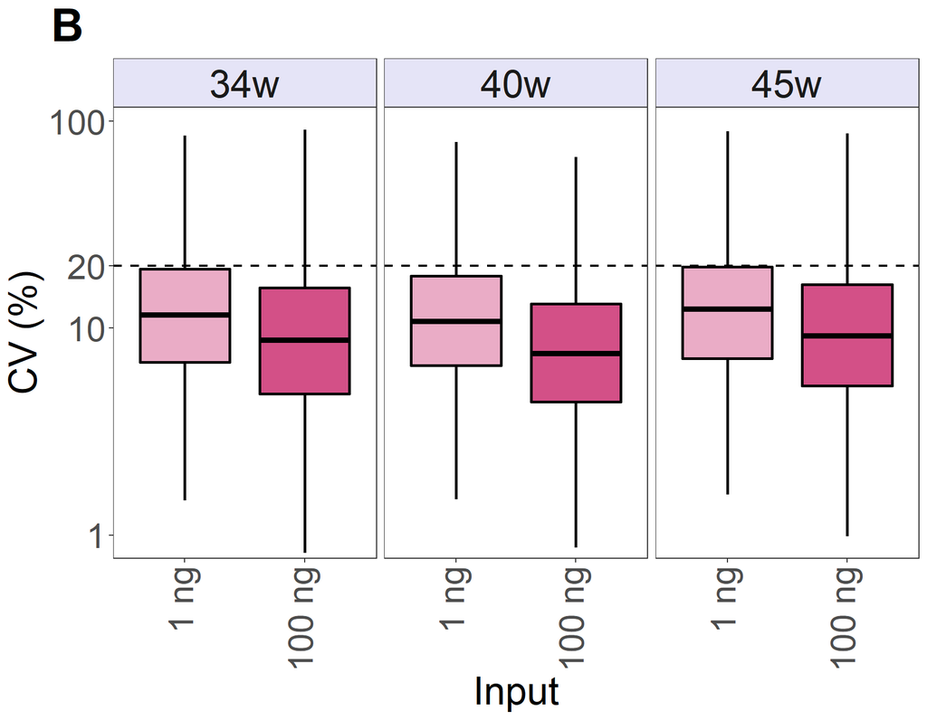

```r
lim <-
  c(boxplot.stats(log10(CV_win_joined[CV_win_joined$method ==
                                    "34w",]$CV*100))$stats[c(1,5)],
    boxplot.stats(log10(CV_win_joined[CV_win_joined$method ==
                                    "LITDIA_Normal",]$CV*100))$stats[c(1,5)],
    boxplot.stats(log10(CV_win_joined[CV_win_joined$method ==
                                    "45w",]$CV*100))$stats[c(1,5)])
lim <- c(min(lim), max(lim))

CV_win_plot <- CV_win_joined %>%
  ggplot(aes(x = input,
             y = CV*100,
             fill = as.factor(indiv)))+
  geom_boxplot(outlier.shape = NA,
               color = "black",
               size = 0.9)+
  scale_fill_manual(values = rep(c("#EAACC6","#D35087"),3)) +
  scale_y_log10(breaks = c(1, 10, 20, 100),
                limits = c(0.08, 190))+
  geom_hline(yintercept = 20,
             linetype = "dashed",
             size = 0.8)+
  labs(x = "Input",
       y = "CV (%)",
       title = "B")+
  theme(legend.position = "none",
        plot.title = element_text(size = 32, face = "bold",
                                  hjust = -0.08),
        panel.grid = element_blank(),
        axis.title = element_text(size = 27),
        axis.text = element_text(size = 24),
        axis.text.x = element_text(angle = 90, vjust = 0.3, hjust = 1),
        strip.text.x = element_text(size = 27),
        strip.background = element_rect(fill = "#E5E4F7"))+
  facet_wrap(~method, labeller = labeller(method =
                                            c("34w" = "34w",
                                              "LITDIA_Normal" = "40w",
                                              "45w" = "45w"))) +
  coord_cartesian(ylim = 10^(lim))
CV_win_plot
```

# 11 Figure 2

```r
fig2 <- id_win_plot + CV_win_plot + plot_layout(widths = c(1, 2))
```

# 12 Points across peak

## 12.1 Load data

## 12.2 violin plot

### 12.2.1 1 ng

```r
pp_Turbo_40SPD_1 <- read.csv2(paste0(pp_path, "PPP_LIT_Turbo_DIA_1ng_40SPD_1CV.tsv"), sep = "/")
pp_Turbo_40SPD_1$indiv <- "Turbo_40SPD_1_"

pp_Rapid_40SPD_1 <- read.csv2(paste0(pp_path, "PPP_LIT_Rapid_DIA_1ng_40SPD_1CV.tsv"), sep = "/")
pp_Rapid_40SPD_1$indiv <- "Rapid_40SPD_1_"

pp_Normal_40SPD_1 <- read.csv2(paste0(pp_path, "PPP_LIT_Normal_DIA_1ng_40SPD_1CV.tsv"), sep = "/")
pp_Normal_40SPD_1$indiv <- "Normal_40SPD_1_"

pp_Rapid_20SPD_1 <- read.csv2(paste0(pp_path, "PPP_LIT_Rapid_DIA_1ng_20SPD_1CV.tsv"), sep = "/")
pp_Rapid_20SPD_1$indiv <- "Rapid_20SPD_1_"

pp_Normal_20SPD_1 <- read.csv2(paste0(pp_path, "PPP_LIT_Normal_DIA_1ng_20SPD_1CV.tsv"), sep = "/")
pp_Normal_20SPD_1$indiv <- "Normal_20SPD_1_"

pp_Enhanced_20SPD_1 <- read.csv2(paste0(pp_path, "PPP_LIT_Enhanced_DIA_1ng_20SPD_1CV.tsv"), sep = "/")
pp_Enhanced_20SPD_1$indiv <- "Enhanced_20SPD_1_"
```

### 12.2.2 5 ng

```r
pp_Turbo_40SPD_5 <- read.csv2(paste0(pp_path, "PPP_LIT_Turbo_DIA_5ng_40SPD_1CV.tsv"), sep = "/")
pp_Turbo_40SPD_5$indiv <- "Turbo_40SPD_5_"

pp_Rapid_40SPD_5 <- read.csv2(paste0(pp_path, "PPP_LIT_Rapid_DIA_5ng_40SPD_1CV.tsv"), sep = "/")
pp_Rapid_40SPD_5$indiv <- "Rapid_40SPD_5_"

pp_Normal_40SPD_5 <- read.csv2(paste0(pp_path, "PPP_LIT_Normal_DIA_5ng_40SPD_1CV.tsv"), sep = "/")
pp_Normal_40SPD_5$indiv <- "Normal_40SPD_5_"

pp_Rapid_20SPD_5 <- read.csv2(paste0(pp_path, "PPP_LIT_Rapid_DIA_5ng_20SPD_1CV.tsv"), sep = "/")
pp_Rapid_20SPD_5$indiv <- "Rapid_20SPD_5_"

pp_Normal_20SPD_5 <- read.csv2(paste0(pp_path, "PPP_LIT_Normal_DIA_5ng_20SPD_1CV.tsv"), sep = "/")
pp_Normal_20SPD_5$indiv <- "Normal_20SPD_5_"

pp_Enhanced_20SPD_5 <- read.csv2(paste0(pp_path, "PPP_LIT_Enhanced_DIA_5ng_20SPD_1CV.tsv"), sep = "/")
pp_Enhanced_20SPD_5$indiv <- "Enhanced_20SPD_5_"
```

### 12.2.3 10 ng

```r
pp_Turbo_40SPD_10 <- read.csv2(paste0(pp_path, "PPP_LIT_Turbo_DIA_10ng_40SPD_1CV.tsv"), sep = "/")
pp_Turbo_40SPD_10$indiv <- "Turbo_40SPD_10_"

pp_Rapid_40SPD_10 <- read.csv2(paste0(pp_path, "PPP_LIT_Rapid_DIA_10ng_40SPD_1CV.tsv"), sep = "/")
pp_Rapid_40SPD_10$indiv <- "Rapid_40SPD_10_"

pp_Normal_40SPD_10 <- read.csv2(paste0(pp_path, "PPP_LIT_Normal_DIA_10ng_40SPD_1CV.tsv"), sep = "/")
pp_Normal_40SPD_10$indiv <- "Normal_40SPD_10_"

pp_Rapid_20SPD_10 <- read.csv2(paste0(pp_path, "PPP_LIT_Rapid_DIA_10ng_20SPD_1CV.tsv"), sep = "/")
pp_Rapid_20SPD_10$indiv <- "Rapid_20SPD_10_"

pp_Normal_20SPD_10 <- read.csv2(paste0(pp_path, "PPP_LIT_Normal_DIA_10ng_20SPD_1CV.tsv"), sep = "/")
pp_Normal_20SPD_10$indiv <- "Normal_20SPD_10_"

pp_Enhanced_20SPD_10 <- read.csv2(paste0(pp_path, "PPP_LIT_Enhanced_DIA_10ng_20SPD_1CV.tsv"), sep = "/")
pp_Enhanced_20SPD_10$indiv <- "Enhanced_20SPD_10_"
```

### 12.2.4 100 ng

```r
pp_Turbo_40SPD_100 <- read.csv2(paste0(pp_path, "PPP_LIT_Turbo_DIA_100ng_40SPD_1CV.tsv"), sep = "/")
pp_Turbo_40SPD_100$indiv <- "Turbo_40SPD_100_"

pp_Rapid_40SPD_100 <- read.csv2(paste0(pp_path, "PPP_LIT_Rapid_DIA_100ng_40SPD_1CV.tsv"), sep = "/")
pp_Rapid_40SPD_100$indiv <- "Rapid_40SPD_100_"

pp_Normal_40SPD_100 <- read.csv2(paste0(pp_path, "PPP_LIT_Normal_DIA_100ng_40SPD_1CV.tsv"), sep = "/")
pp_Normal_40SPD_100$indiv <- "Normal_40SPD_100_"

pp_Rapid_20SPD_100 <- read.csv2(paste0(pp_path, "PPP_LIT_Rapid_DIA_100ng_20SPD_1CV.tsv"), sep = "/")
pp_Rapid_20SPD_100$indiv <- "Rapid_20SPD_100_"

pp_Normal_20SPD_100 <- read.csv2(paste0(pp_path, "PPP_LIT_Normal_DIA_100ng_20SPD_1CV.tsv"), sep = "/")
pp_Normal_20SPD_100$indiv <- "Normal_20SPD_100_"
```

### 12.2.5 Join

```r
colnames(pp_Turbo_40SPD_1) <- colnames(pp_Turbo_40SPD_5) <- colnames(pp_Turbo_40SPD_10) <-
  colnames(pp_Turbo_40SPD_100) <- colnames(pp_Rapid_40SPD_1) <- colnames(pp_Rapid_40SPD_5) <-
  colnames(pp_Rapid_40SPD_10) <- colnames(pp_Rapid_40SPD_100) <- colnames(pp_Normal_40SPD_1) <-
  colnames(pp_Normal_40SPD_5) <- colnames(pp_Normal_40SPD_10) <- colnames(pp_Normal_40SPD_100) <-
  colnames(pp_Rapid_20SPD_1) <- colnames(pp_Rapid_20SPD_5) <- colnames(pp_Rapid_20SPD_10) <-
  colnames(pp_Rapid_20SPD_100) <- colnames(pp_Normal_20SPD_1) <- colnames(pp_Normal_20SPD_5) <-
  colnames(pp_Normal_20SPD_10) <- colnames(pp_Normal_20SPD_100) <- colnames(pp_Enhanced_20SPD_1) <-
  colnames(pp_Enhanced_20SPD_5) <- colnames(pp_Enhanced_20SPD_10) <-
  c("Points_per_Peaks", "indiv")
#

pp <- rbind(pp_Turbo_40SPD_1, pp_Turbo_40SPD_5, pp_Turbo_40SPD_10, pp_Turbo_40SPD_100,
            pp_Rapid_40SPD_1, pp_Rapid_40SPD_5, pp_Rapid_40SPD_10, pp_Rapid_40SPD_100,
            pp_Normal_40SPD_1, pp_Normal_40SPD_5, pp_Normal_40SPD_10, pp_Normal_40SPD_100,
            pp_Rapid_20SPD_1, pp_Rapid_20SPD_5, pp_Rapid_20SPD_10, pp_Rapid_20SPD_100,
            pp_Normal_20SPD_1, pp_Normal_20SPD_5, pp_Normal_20SPD_10, pp_Normal_20SPD_100,
            pp_Enhanced_20SPD_1, pp_Enhanced_20SPD_5, pp_Enhanced_20SPD_10)

pp$input <- NA
pp$input[grepl("1_", pp$indiv)] <- "1 ng"
pp$input[grepl("5_", pp$indiv)] <- "5 ng"
pp$input[grepl("10_", pp$indiv)] <- "10 ng"
pp$input[grepl("100_", pp$indiv)] <- "100 ng"
pp$input <- factor(pp$input, levels = unique(pp$input))

pp$IT <- NA
pp$IT[grepl("20SPD", pp$indiv)] <- "20 SPD"
pp$IT[grepl("40SPD", pp$indiv)] <- "40 SPD"
pp$IT <- factor(pp$IT, levels = c("40 SPD", "20 SPD"))

pp$method <- NA
pp$method[grepl("Turbo", pp$indiv)] <- "Turbo"
pp$method[grepl("Rapid", pp$indiv)] <- "Rapid"
pp$method[grepl("Normal", pp$indiv)] <- "Normal"
pp$method[grepl("Enhanced", pp$indiv)] <- "Enhanced"
pp$method <- factor(pp$method, levels = c("Turbo", "Rapid", "Normal", "Enhanced"))
```

### 12.2.6 plot

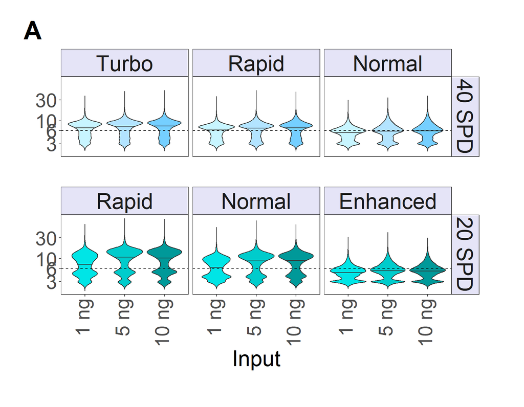

```r
palette1 <-c("#C8F5FF", "#75CFFF", "#B3E4FF")

plot_40SPD <- pp %>%
  filter(IT == "40 SPD" &
           input != "100 ng") %>%
  ggplot(aes(x = input, y = Points_per_Peaks,
             fill = as.factor(indiv)))+
  geom_violin(draw_quantiles = 0.5) +
  scale_fill_manual(values = rep(palette1,3)) +
  facet_grid(IT ~ method)+
  scale_y_log10() +
  geom_hline(yintercept = 6,
             linetype = "dashed") +
  labs(title = "A")+
  theme(legend.position = "none",
        panel.grid = element_blank(),
        axis.text = element_text(size = 24),
        strip.text = element_text(size = 27),
        strip.background = element_rect(fill = "#E5E4F7"),
        plot.margin = margin(t = 20,
                             r = 50,
                             b = 20,
                             l = 10),
        plot.title = element_text(size = 32, face = "bold",
                                  hjust = -0.1))

palette2 <- c("#00E5E6", "#009999", "#00CCCC")

plot_20SPD <- pp %>%
  filter(IT == "20 SPD" &
           input != "100 ng") %>%
  ggplot(aes(x = input, y = Points_per_Peaks,
             fill = as.factor(indiv)))+
  geom_violin(draw_quantiles = 0.5) +
  scale_fill_manual(values = rep(palette2,3)) +
  facet_grid(IT ~ method)+
  scale_y_log10() +
  geom_hline(yintercept = 6,
             linetype = "dashed") +
  labs(x = "Input",
       y = "Points across a peak") +
  theme(legend.position = "none",
        panel.grid = element_blank(),
        axis.title = element_text(size = 27),
        axis.text = element_text(size = 24),
        axis.text.x = element_text(angle = 90, vjust = 0.3, hjust = 1),
        strip.text = element_text(size = 27),
        strip.background = element_rect(fill = "#E5E4F7"),
        plot.margin = margin(t = 15,
                             r = 50,
                             b = 40,
                             l = 10))

limit <- 10^c(min(c(layer_scales(plot_40SPD)$y$get_limits(),
                    layer_scales(plot_20SPD)$y$get_limits())),
              max(c(layer_scales(plot_40SPD)$y$get_limits(),
                    layer_scales(plot_20SPD)$y$get_limits())))

pp_plot <- (plot_40SPD +
    scale_y_log10(limits = limit,
                   breaks = c(3, 6, 10, 30))+
    theme(axis.title = element_blank(),
          axis.text.x = element_blank(),
          axis.ticks.x = element_blank()))/
  (plot_20SPD +
     scale_y_log10(limits = limit,
                   breaks = c(3, 6, 10, 30))+
     theme(axis.title.y = element_text(hjust = -2.5, vjust = 1)))
pp_plot
```

## 12.3 PPP >= 6

```r
pp$acc <- pp$Points_per_Peaks >= 6

id_acc_40SPD <- pp %>%
  group_by(indiv, IT, input, method) %>%
  summarise(n_acc = sum(acc)) %>%
  filter(IT == "40 SPD" &
           input != "100 ng") %>%
  ggplot(aes(x = input, y = n_acc/3, group = method, color = method)) +
  geom_line(size = 2.5) +
  geom_point(size = 4) +
  theme_classic2() +
  scale_color_manual(values = c("#d3c582FF", "#6FB382FF", "#92BBD9FF"))+
  labs(color = "Scanning method",
       x = "Input",
       title = "B")+
  theme(legend.position = c(0.148, 0.85),
        legend.background = element_blank(),
        legend.title = element_blank(),
        legend.text = element_text(size = 22),
        axis.text = element_text(size = 24),
        axis.title = element_text(size = 27),
        legend.key.size = unit(0.9, "cm"),
        axis.title.y = element_blank(),
        plot.margin = margin(t = 0,
                             r = 58,
                             b = 54,
                             l = 10),
        plot.title = element_text(size = 32, face = "bold",
                                  hjust = -0.37))+
  annotate("text", x = 3.5, y = 7500, label = "40 SPD", angle = -90, size = 9.5)

id_acc_20SPD <- pp %>%
  group_by(indiv, IT, input, method) %>%
  summarise(n_acc = sum(acc)) %>%
  filter(IT == "20 SPD"&
           input != "100 ng") %>%
  ggplot(aes(x = input, y = n_acc/3, group = method, color = method)) +
  geom_line(size = 2.5) +
  geom_point(size = 4) +
  theme_classic2() +
  scale_color_manual(values = c("#6FB382FF", "#92BBD9FF", "#4D6D93FF")) +
  labs(color = "Scanning method",
       x = "Input",
       y = "Peptides with number of points across a peak >= 6")+
  theme(legend.position = c(0.18, 0.85),
        legend.background = element_blank(),
        legend.title = element_blank(),
        legend.text = element_text(size = 22),
        axis.text = element_text(size = 24),
        axis.title = element_text(size = 27),
        legend.key.size = unit(0.9, "cm"),
        axis.title.y = element_text(hjust = 0.2,
                                    vjust = 2.4),
        plot.margin = margin(t = 15,
                             r = 58,
                             b = 40,
                             l = 10),
        axis.text.x = element_text(angle = 90, vjust = 0.3, hjust = 1))+
  annotate("text", x = 3.5, y = 7500, label = "20 SPD", angle = -90, size = 9.5)

limit <- c(min(c(layer_scales(id_acc_40SPD)$y$get_limits(),
                 layer_scales(id_acc_20SPD)$y$get_limits())),
max(c(layer_scales(id_acc_40SPD)$y$get_limits(), layer_scales(id_acc_20SPD)$y$get_limits())))

id_acc <- (id_acc_40SPD +
             scale_y_continuous(limits = limit, breaks = c(2500, 7500, 12500))+
            theme(axis.title.x = element_blank(),
                  axis.text.x = element_blank()))/
(id_acc_20SPD +
   scale_y_continuous(limits = limit, breaks = c(2500, 7500, 12500)))
```

## 12.4 Figure 4

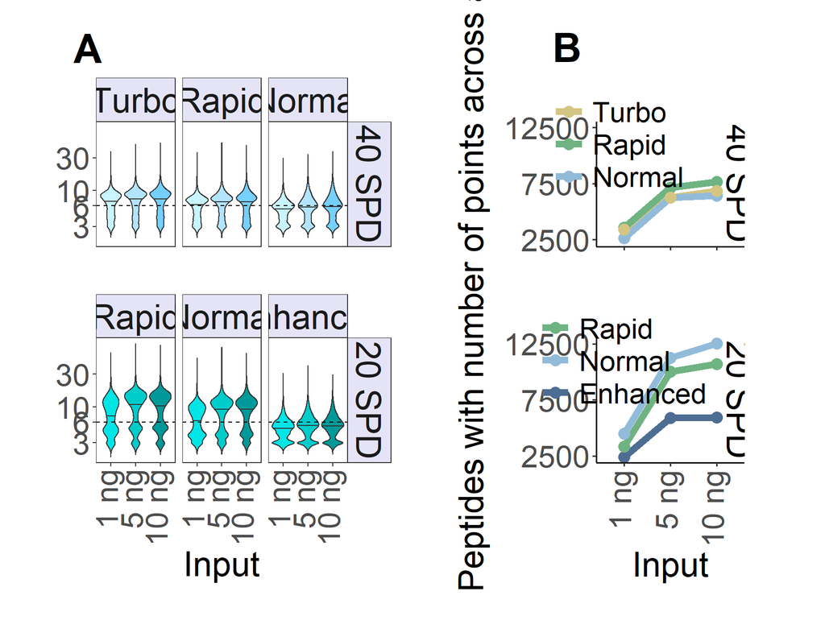

```r
id_acc <- (id_acc_40SPD +
             scale_y_continuous(limits = limit, breaks = c(2500, 7500, 12500))+
            theme(axis.title.x = element_blank(),
                  axis.text.x = element_blank()))/
(id_acc_20SPD +
   scale_y_continuous(limits = limit, breaks = c(2500, 7500, 12500)))

wrap_plots(pp_plot, id_acc)+ plot_layout(widths = c(1.7, 1))
```